# Final Project: Monte Carlo Uncertainty, Scaling Laws, and Geometry Stress Tests for Bayesian Samplers

A reproducible PyMC benchmark spanning applied models, repeated-seed uncertainty quantification, high-dimensional scaling, and Neal’s Funnel

Authors

Steven Chen

Yuan Lei

Alex Li

Ziqi Mu

Yuzhou Peng

## 1 Introduction

Our original proposal asked a practical question from computational Bayesian statistics: when do more sophisticated MCMC methods such as Hamiltonian Monte Carlo (HMC) and the No-U-Turn Sampler (NUTS) justify their extra computational cost relative to simpler baselines such as Metropolis-Hastings?

Besides comparison of algorithms from a simple Monte Carlo samling task, this project seeks to include more variables in the experiments to study performance of these algorithms from more perspectives. Specifically, this project will conduct following experiments:

1. Repeated-seed Monte Carlo benchmarking, so the benchmark itself has uncertainty quantification rather than only point estimates.
2. Dimension-scaling experiments, so we can estimate how statistical efficiency decays as parameter dimension increases.
3. Exact-posterior accuracy checks on a known Gaussian target, so efficiency can be compared to actual estimation error.
4. Approximate-inference comparisons, adding mean-field and full-rank ADVI to the benchmark.
5. Budget-response curves, so we can study how extra computation changes performance rather than relying on one fixed budget.
6. Centered-versus-non-centered parameterization checks in the hierarchical model.
7. Posterior-geometry stress tests, centered on Neal’s Funnel, to study sampler behavior on pathologically hard targets.
8. Posterior predictive checks to see whether the sampled posterior can recover similar data to what is observed
9. Simulation-based calibration to verify whether the posterior sample produced by algorithms are similar to the actual posterior distribution

The purpose of this project is to explore how sampler performance varies (1) across applied workloads, (2) across random seeds, (3) across dimensions. And how they are sensitive to parametrizations, difficult parameter geometry. Besides performance, this project checks whehter samplers recover real posterior.

This report studies eight related questions:

1. Which samplers perform best on a realistic portfolio of applied Bayesian models?
2. How much uncertainty is there in the benchmark itself when we repeat runs under different random seeds?
3. How quickly does efficiency degrade with increasing parameter dimension?
4. Which exact samplers are most accurate when the true posterior is known?
5. How do approximate methods such as ADVI compare to exact samplers on speed and posterior error?
6. Which methods improve meaningfully when we increase the computational budget?
7. How much do centered versus non-centered parameterizations change the apparent sampler ranking?
8. Which samplers remain reliable when posterior geometry becomes genuinely pathological?

## 2 Study Design

The notebook is organized as ten connected benchmark blocks:

1. A broad applied battery of five model classes.
2. A repeated-seed uncertainty study over the same applied scenarios.
3. A high-dimensional scaling-law study on correlated Gaussian targets.
4. An exact-posterior accuracy check on a medium-high-dimensional Gaussian target.
5. An approximate-inference comparison using mean-field and full-rank ADVI.
6. A budget-response study over short, medium, and long compute budgets.
7. A hierarchical parameterization study comparing centered and non-centered forms.
8. A dedicated Neal’s Funnel stress test.
9. Posterior predictive checks for the applied models.
10. Simulation-based calibration checks on representative easy and hierarchical targets.

This structure deliberately balances breadth and depth. The applied battery makes the report feel useful to practitioners, while the exact-accuracy, approximation, budget, parameterization, and funnel sections move it much closer to a computational-statistics study.

### 2.1 Benchmark Assets

All reported HTML results below use the same PyMC sampling configuration: 4 chains, 500 tuning iterations (burn-in), and 1000 retained draws per chain. That gives 4000 post-warmup draws per model-sampler fit.

| Block | Purpose | Runs | Seeds | Sampling configuration |
| --- | --- | --- | --- | --- |
| Applied battery | Single-seed cross-scenario benchmark for breadth | 20 | 1 | 4 chains x (500 tune + 1000 draws per chain) |
| Repeated-seed uncertainty | Estimate benchmark variability and win probabilities | 400 | 20 | 4 chains x (500 tune + 1000 draws per chain) |
| Scaling law study | Estimate ESS/sec ~ p^(-alpha) under correlation stress | 160 | 8 | 4 chains x (500 tune + 1000 draws per chain) |
| Exact-posterior accuracy | Measure posterior mean, variance, and coverage error against a known Gaussian target | 32 | 8 | 4 chains x (500 tune + 1000 draws per chain) |
| Approximate inference | Compare ADVI methods to exact samplers on the same known target | 16 | 8 | 10000 optimization steps + 4000 posterior draws |
| Budget-response study | Trace runtime-accuracy tradeoffs on the exact Gaussian target and full-sampler budget diagnostics on harder targets | 108 | 4 for Gaussian; 2 for hard targets | Short: NUTS = 4 chains x (100 tune + 200 draws per chain); ADVI = 500 optimization steps + 4000 posterior draws |
| Parameterization study | Compare centered and non-centered hierarchical formulations | 40 | 10 | 4 chains x (500 tune + 1000 draws per chain) |
| Neal’s Funnel | Stress-test geometry adaptation on a pathological posterior | 80 | 20 | 4 chains x (500 tune + 1000 draws per chain) |

| Sampler | Family | Uses gradients |
| --- | --- | --- |
| Metropolis-Hastings | Random-walk MH | No |
| DE-Metropolis | Differential evolution MH | No |
| Hamiltonian MC | Static HMC | Yes |
| NUTS | Dynamic HMC | Yes |

| Scenario | Data source | Likelihood | Observations | Approx. parameters | Why included |
| --- | --- | --- | --- | --- | --- |
| Gaussian | Marginal response from scikit-learn diabetes | Normal likelihood | 260 | 2 | An easy baseline where simple samplers can still look competitive. |
| Linear regression | scikit-learn diabetes dataset | Gaussian regression | 240 | 12 | A medium-dimensional continuous model where gradients should matter. |
| Logistic regression | scikit-learn breast cancer dataset | Bernoulli-logit regression | 569 | 9 | A non-Gaussian classification task with correlated predictors. |
| Hierarchical | Synthetic grouped outcomes | Varying-intercept Gaussian model | 303 | 22 | A structured multilevel model with shrinkage and uneven group sizes. |
| Zero-inflated count | Synthetic insurance-style claims | Zero-inflated Poisson | 300 | 22 | A hard applied target combining sparse counts, many zeros, and linked latent structure. |

## 3 Applied Portfolio Benchmark

We begin with a broad single-seed battery. This section provides the same kind of applied overview as the previous version of the project, but now it serves as only the first layer of the analysis rather than the whole story.

```python
portfolio_models = {scenario_name: scenarios[scenario_name].builder() for scenario_name in scenario_order}
portfolio_rows = []
portfolio_idatas = {scenario_name: {} for scenario_name in scenario_order}

for scenario_name in scenario_order:
    scenario = scenarios[scenario_name]
    model = portfolio_models[scenario_name]
    for sampler_name in sampler_order:
        idata, metrics = run_model_with_sampler(
            model=model,
            sampler_name=sampler_name,
            summary_vars=scenario.summary_vars,
            sample_config=PORTFOLIO_CONFIG,
            seed=PORTFOLIO_SEED,
        )
        portfolio_idatas[scenario_name][sampler_name] = idata
        portfolio_rows.append(
            {
                "scenario": scenario_name,
                "scenario_short": scenario.short_name,
                "scenario_abbrev": scenario_abbrev[scenario_name],
                "sampler": sampler_name,
                **metrics,
            }
        )

portfolio_results_df = finalize_results_df(pd.DataFrame(portfolio_rows), scenario_order)
portfolio_results_df["runtime_rank"] = portfolio_results_df.groupby("scenario", observed=True)["runtime_s"].rank(method="dense", ascending=True)
portfolio_results_df["ess_rank"] = portfolio_results_df.groupby("scenario", observed=True)["ess_per_second"].rank(method="dense", ascending=False)
portfolio_results_df["stability_rank"] = portfolio_results_df.groupby("scenario", observed=True)["max_rhat"].rank(method="dense", ascending=True)
portfolio_results_df["composite_rank"] = portfolio_results_df[["runtime_rank", "ess_rank", "stability_rank"]].mean(axis=1)

leaderboard_df = (
    portfolio_results_df.groupby("sampler", observed=True)
    .agg(
        mean_runtime_s=("runtime_s", "mean"),
        mean_ess_per_second=("ess_per_second", "mean"),
        mean_max_rhat=("max_rhat", "mean"),
        reliable_scenarios=("reliable_run", "sum"),
        mean_composite_rank=("composite_rank", "mean"),
    )
    .reset_index()
    .sort_values(["mean_composite_rank", "mean_max_rhat", "mean_runtime_s"])
)

scenario_winners_df = pd.DataFrame(
    [
        {
            "Scenario": scenario_name,
            "Fastest": sub.loc[sub["runtime_s"].idxmin(), "sampler"],
            "Best ESS/s": sub.loc[sub["ess_per_second"].idxmax(), "sampler"],
            "Best stability": sub.loc[sub["max_rhat"].idxmin(), "sampler"],
            "Best composite": sub.loc[sub["composite_rank"].idxmin(), "sampler"],
        }
        for scenario_name, sub in portfolio_results_df.groupby("scenario", observed=True)
    ]
)
```

| sampler | mean_runtime_s | mean_ess_per_second | mean_max_rhat | reliable_scenarios | mean_composite_rank |
| --- | --- | --- | --- | --- | --- |
| Hamiltonian MC | 238.884 | 36.761 | 1 | 5 | 1.867 |
| NUTS | 284.427 | 15.808 | 1 | 5 | 2.2 |
| Metropolis-Hastings | 233.272 | 2.975 | 1.238 | 3 | 2.4 |
| DE-Metropolis | 211.855 | 3.971 | 2.182 | 1 | 2.4 |

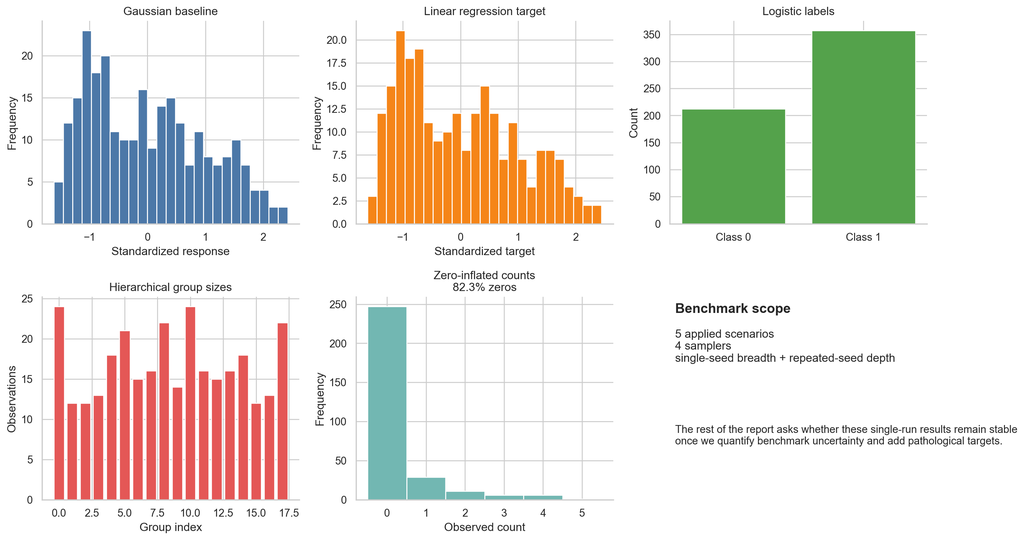

A compact visual summary of the applied benchmark portfolio.

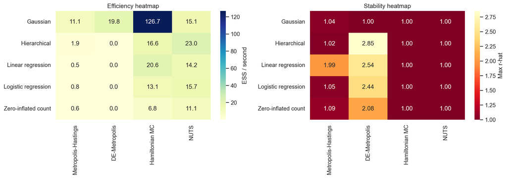

Single-run portfolio view: ESS per second and maximum r-hat.

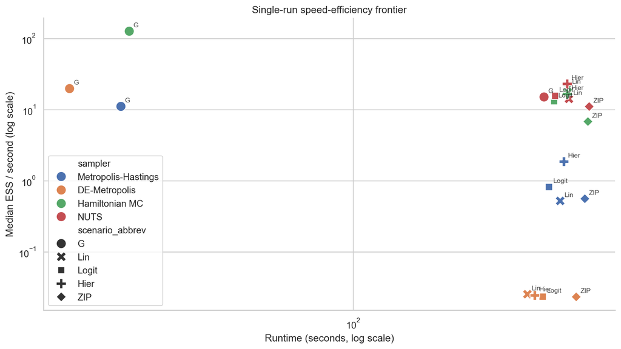

Single-run speed-efficiency frontier. Upper-left points are most attractive.

| Scenario | Fastest | Best ESS/s | Best stability | Best composite |
| --- | --- | --- | --- | --- |
| Gaussian location model | DE-Metropolis | Hamiltonian MC | DE-Metropolis | DE-Metropolis |
| Bayesian linear regression | DE-Metropolis | Hamiltonian MC | Hamiltonian MC | Hamiltonian MC |
| Bayesian logistic regression | DE-Metropolis | NUTS | Hamiltonian MC | Hamiltonian MC |
| Hierarchical regression | DE-Metropolis | NUTS | Hamiltonian MC | Hamiltonian MC |
| Zero-inflated count regression | DE-Metropolis | NUTS | Hamiltonian MC | Hamiltonian MC |

The broad single-seed benchmark already shows a pattern that will keep reappearing: simple random-walk methods often look attractive on raw runtime, but geometry-aware samplers dominate once we care about reliable effective sampling. The problem is that a single run cannot tell us how stable those rankings really are. That is the purpose of the next section.

## 4 Repeated-Seed Monte Carlo Benchmarking

Single-run benchmarks produce point estimates. This section upgrades the study by running the applied battery repeatedly under different random seeds so the benchmark itself has uncertainty quantification.

For each scenario-sampler pair, we now report:

1. Mean performance over repeated runs.
2. Empirical 95% intervals across repeated runs.
3. Reliability frequency.
4. The probability that a sampler is the best within a scenario.

```python
repeated_models = {scenario_name: scenarios[scenario_name].builder() for scenario_name in scenario_order}
repeated_rows = []

for scenario_name in scenario_order:
    scenario = scenarios[scenario_name]
    model = repeated_models[scenario_name]
    for replicate, seed in enumerate(REPEATED_SEEDS, start=1):
        for sampler_name in sampler_order:
            _, metrics = run_model_with_sampler(
                model=model,
                sampler_name=sampler_name,
                summary_vars=scenario.summary_vars,
                sample_config=REPEATED_CONFIG,
                seed=seed,
            )
            repeated_rows.append(
                {
                    "scenario": scenario_name,
                    "scenario_short": scenario.short_name,
                    "replicate": replicate,
                    "seed": seed,
                    "sampler": sampler_name,
                    **metrics,
                }
            )

repeated_results_df = finalize_results_df(pd.DataFrame(repeated_rows), scenario_order)
repeated_summary_df = summarize_repeated_block(repeated_results_df, scenario_order)

repeated_display_df = repeated_summary_df.assign(
    **{
        "ESS/sec mean [95% interval]": [
            interval_string(row.ess_mean, row.ess_low, row.ess_high, digits=1)
            for row in repeated_summary_df.itertuples()
        ],
        "Runtime mean [95% interval]": [
            interval_string(row.runtime_mean, row.runtime_low, row.runtime_high, digits=2)
            for row in repeated_summary_df.itertuples()
        ],
        "Mean max r-hat": repeated_summary_df["rhat_mean"].round(3),
        "Reliability rate": repeated_summary_df["reliability_rate"].round(2),
        "Pr(best ESS/s)": repeated_summary_df["pr_best_ess"].round(2),
    }
)[
    [
        "scenario_short",
        "sampler",
        "ESS/sec mean [95% interval]",
        "Runtime mean [95% interval]",
        "Mean max r-hat",
        "Reliability rate",
        "Pr(best ESS/s)",
    ]
].rename(columns={"scenario_short": "Scenario", "sampler": "Sampler"})

prob_best_heatmap = repeated_summary_df.pivot(index="scenario_short", columns="sampler", values="pr_best_ess")
reliability_heatmap = repeated_summary_df.pivot(index="scenario_short", columns="sampler", values="reliability_rate")

hardest_applied_scenario = "Zero-inflated count regression"
zip_pairwise_ess = pairwise_probability_matrix(
    repeated_results_df.loc[repeated_results_df["scenario"] == hardest_applied_scenario],
    metric="ess_per_second",
    higher_is_better=True,
)
```

| Scenario | Sampler | ESS/sec mean [95% interval] | Runtime mean [95% interval] | Mean max r-hat | Reliability rate | Pr(best ESS/s) |
| --- | --- | --- | --- | --- | --- | --- |
| Gaussian | Metropolis-Hastings | 9.5 [1.6, 22.2] | 82.29 [18.71, 216.40] | 1 | 1 | 0 |
| Gaussian | DE-Metropolis | 11.5 [2.2, 23.5] | 88.06 [21.68, 215.55] | 1 | 1 | 0 |
| Gaussian | Hamiltonian MC | 71.6 [17.9, 154.7] | 102.18 [26.15, 218.03] | 1 | 1 | 1 |
| Gaussian | NUTS | 74.1 [14.5, 157.1] | 99.11 [21.89, 218.07] | 1 | 1 | 0 |
| Linear regression | Metropolis-Hastings | 2.5 [0.5, 6.8] | 119.42 [26.35, 295.44] | 2 | 0 | 0 |
| Linear regression | DE-Metropolis | 0.1 [0.0, 0.3] | 99.86 [20.51, 247.72] | 3 | 0 | 0 |
| Linear regression | Hamiltonian MC | 79.1 [15.3, 167.8] | 117.44 [30.12, 311.89] | 1 | 1 | 1 |
| Linear regression | NUTS | 52.0 [12.0, 109.6] | 114.01 [37.00, 313.44] | 1 | 1 | 0 |
| Logistic regression | Metropolis-Hastings | 5.2 [1.5, 8.0] | 62.30 [29.66, 154.05] | 1 | 1 | 0 |
| Logistic regression | DE-Metropolis | 0.1 [0.0, 0.2] | 70.21 [27.89, 200.34] | 3 | 0 | 0 |
| Logistic regression | Hamiltonian MC | 70.5 [17.4, 145.6] | 77.36 [26.28, 213.45] | 1 | 1 | 0 |
| Logistic regression | NUTS | 87.0 [19.4, 163.5] | 75.69 [26.20, 216.86] | 1 | 1 | 1 |
| Hierarchical | Metropolis-Hastings | 8.9 [2.3, 20.9] | 105.15 [26.27, 227.70] | 1 | 1 | 0 |
| Hierarchical | DE-Metropolis | 0.2 [0.0, 0.3] | 63.52 [19.49, 192.37] | 3 | 0 | 0 |
| Hierarchical | Hamiltonian MC | 94.4 [24.0, 177.8] | 90.74 [27.28, 211.48] | 1 | 1 | 0 |
| Hierarchical | NUTS | 101.0 [28.6, 206.5] | 103.76 [30.95, 222.63] | 1 | 1 | 1 |
| Zero-inflated count | Metropolis-Hastings | 2.5 [0.6, 4.0] | 94.31 [39.74, 247.26] | 1 | 0 | 0 |
| Zero-inflated count | DE-Metropolis | 0.1 [0.0, 0.2] | 80.35 [31.71, 215.32] | 2 | 0 | 0 |
| Zero-inflated count | Hamiltonian MC | 35.3 [7.8, 53.7] | 86.92 [41.79, 256.31] | 1 | 1 | 0 |
| Zero-inflated count | NUTS | 52.1 [22.5, 82.4] | 80.58 [45.39, 189.56] | 1 | 1 | 1 |

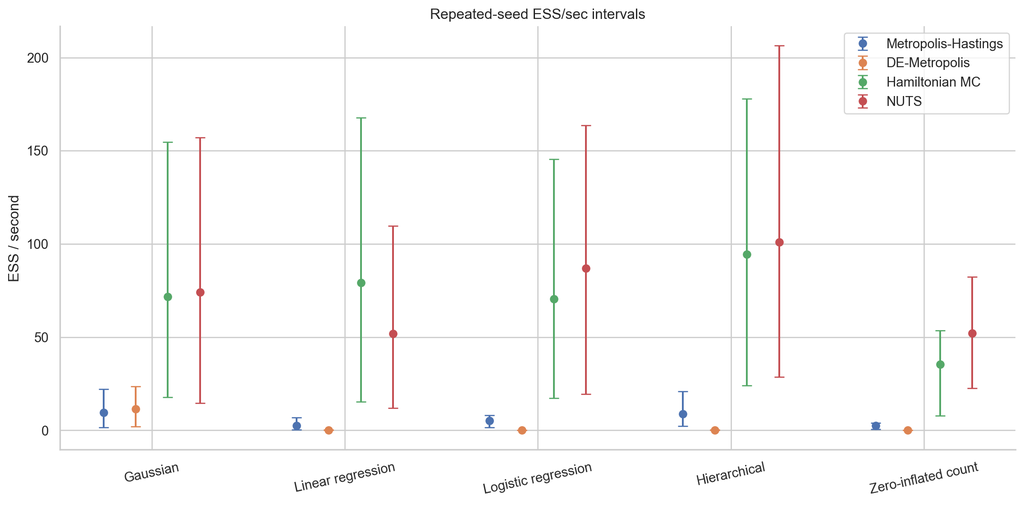

Repeated-seed uncertainty intervals for ESS per second across the applied scenarios.

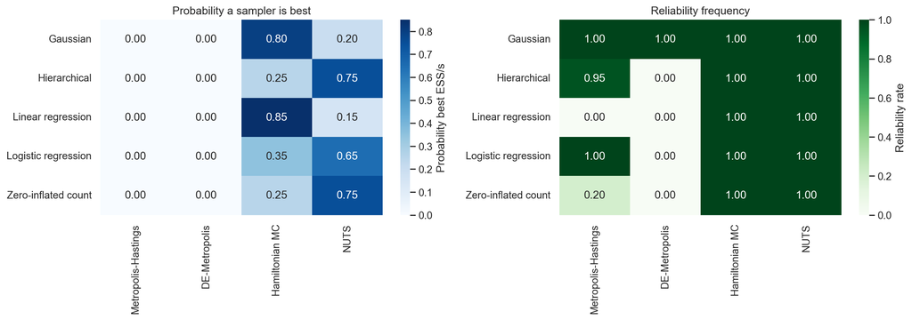

Monte Carlo benchmark uncertainty summarized as probabilities and reliability frequencies.

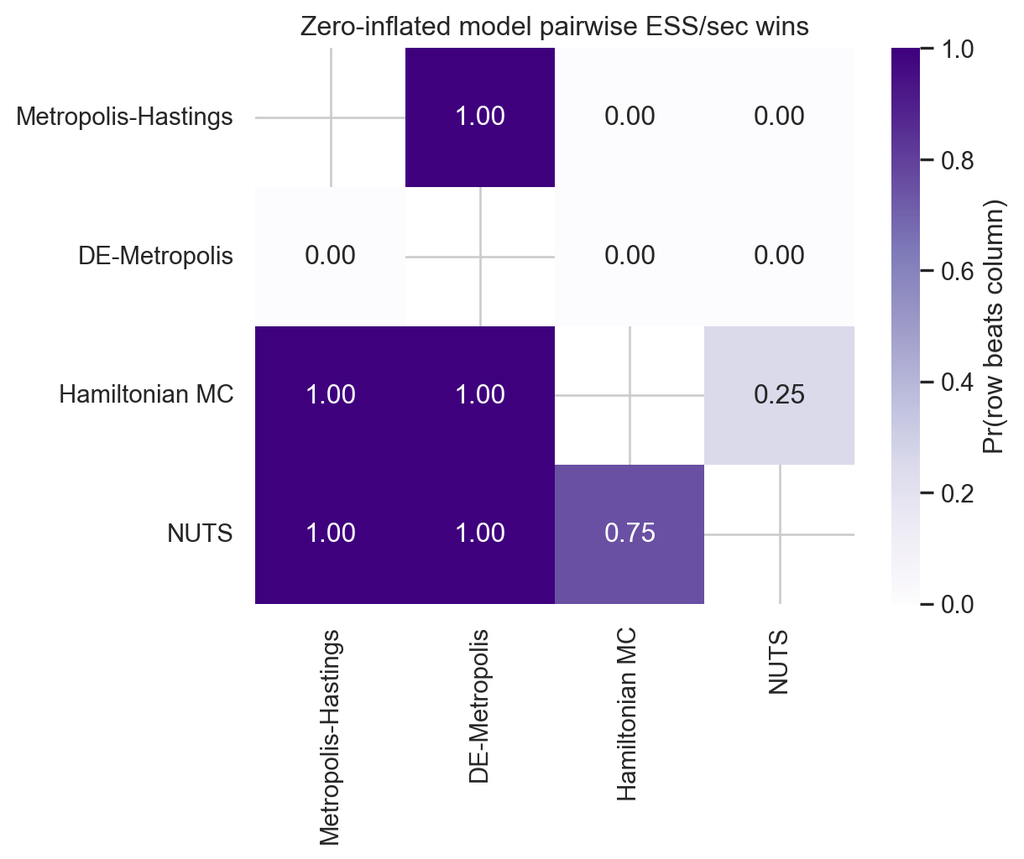

Pairwise win probabilities on ESS/sec for the hardest applied scenario: zero-inflated count regression.

| Scenario | Top sampler by mean ESS/s | Pr(best ESS/s) | Reliability rate |
| --- | --- | --- | --- |
| Gaussian location model | NUTS | 0.2 | 1 |
| Bayesian linear regression | Hamiltonian MC | 0.85 | 1 |
| Bayesian logistic regression | NUTS | 0.65 | 1 |
| Hierarchical regression | NUTS | 0.75 | 1 |
| Zero-inflated count regression | NUTS | 0.75 | 1 |

The repeated-seed study changes the interpretation of the benchmark in an important way. Instead of saying only that a sampler “won” on ESS per second, we can now ask how often that result recurs. In a research or industry setting, that is a much more defensible statement than a single-run ranking.

## 5 Dimension Scaling Laws

The next question is how fast does efficiency decay as the dimension of the target increases?

To study that, we benchmark the samplers on a family of correlated Gaussian targets with fixed condition number $\kappa(\Sigma)=10^3$ and dimensions

1. $p = 2$
2. $p = 10$
3. $p = 50$
4. $p = 100$
5. $p = 250$

We then estimate an empirical scaling law of the form

$$\text{ESS/sec} \propto p^{-\alpha}$$

where smaller $\alpha$ means slower degradation with dimension.

```python
scaling_rows = []
scaling_models = {}
scaling_kappas = {}

for p in DIMENSION_GRID:
    model, condition_number = build_correlated_gaussian_model(p)
    scaling_models[p] = model
    scaling_kappas[p] = condition_number

for p in DIMENSION_GRID:
    model = scaling_models[p]
    for replicate, seed in enumerate(SCALING_SEEDS, start=1):
        for sampler_name in sampler_order:
            _, metrics = run_model_with_sampler(
                model=model,
                sampler_name=sampler_name,
                summary_vars=["theta"],
                sample_config=SCALING_CONFIG,
                seed=seed,
            )
            scaling_rows.append(
                {
                    "scenario": "Correlated Gaussian scaling",
                    "scenario_short": "Scaling",
                    "p": p,
                    "replicate": replicate,
                    "sampler": sampler_name,
                    "condition_number": scaling_kappas[p],
                    **metrics,
                }
            )

scaling_results_df = finalize_results_df(pd.DataFrame(scaling_rows))

scaling_summary_df = (
    scaling_results_df.groupby(["p", "sampler"], observed=True)
    .agg(
        ess_mean=("ess_per_second", "mean"),
        ess_low=("ess_per_second", lambda x: empirical_interval(x)[0]),
        ess_high=("ess_per_second", lambda x: empirical_interval(x)[1]),
        runtime_mean=("runtime_s", "mean"),
    )
    .reset_index()
)

scaling_alpha_rows = []
for sampler_name, sub in scaling_results_df.groupby("sampler", observed=True):
    mean_by_p = sub.groupby("p", observed=True)["ess_per_second"].mean().sort_index()
    ess_vals = mean_by_p.to_numpy(dtype=float)
    p_vals = mean_by_p.index.to_numpy(dtype=float)
    valid = np.isfinite(ess_vals) & (ess_vals > 0)
    if valid.sum() < 2:
        scaling_alpha_rows.append(
            {"Sampler": sampler_name, "Estimated alpha": np.nan,
             "95% interval low": np.nan, "95% interval high": np.nan, "R^2": np.nan}
        )
        continue
    log_p = np.log(p_vals[valid])
    log_ess = np.log(ess_vals[valid])
    slope, intercept = np.polyfit(log_p, log_ess, 1)
    fitted = slope * log_p + intercept
    r_squared = 1 - np.sum((log_ess - fitted) ** 2) / np.sum((log_ess - np.mean(log_ess)) ** 2)
    low_alpha, high_alpha = bootstrap_scaling_alpha(sub)
    scaling_alpha_rows.append(
        {
            "Sampler": sampler_name,
            "Estimated alpha": -float(slope),
            "95% interval low": low_alpha,
            "95% interval high": high_alpha,
            "R^2": float(r_squared),
        }
    )

scaling_alpha_df = pd.DataFrame(scaling_alpha_rows).sort_values("Estimated alpha")
```

| Dimension p | Condition number |
| --- | --- |
| 2 | 1000 |
| 10 | 1000 |
| 50 | 1000 |
| 100 | 1000 |
| 250 | 1000 |

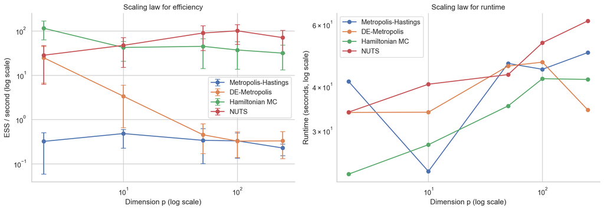

Empirical scaling of ESS per second with parameter dimension on correlated Gaussian targets.

| Sampler | alpha [95% interval] | R^2 |
| --- | --- | --- |
| NUTS | -0.24 [-0.30, -0.16] | 0.759 |
| Metropolis-Hastings | 0.08 [-0.03, 0.15] | 0.298 |
| Hamiltonian MC | 0.23 [0.18, 0.29] | 0.793 |
| DE-Metropolis | 0.96 [0.87, 1.04] | 0.935 |

## 6 Exact-Posterior Accuracy Check

Efficiency metrics are informative, but they are not the same as posterior accuracy. On the correlated Gaussian target family we know the exact distribution, so we can go beyond ESS/sec and ask whether the samplers with the best efficiency also achieve the smallest estimation error in posterior moments.

We focus on the $p=50$ target as a representative medium-high-dimensional case. The exact posterior mean is zero and the exact marginal standard deviations are known from the covariance construction, which lets us measure Monte Carlo error directly.

```python
reference_model, reference_kappa = build_correlated_gaussian_model(REFERENCE_DIM)
reference_chol, _ = make_conditioned_covariance(REFERENCE_DIM)
reference_exact_mean = np.zeros(REFERENCE_DIM)
reference_exact_sd = np.sqrt(np.sum(reference_chol**2, axis=1))
reference_rows = []

for replicate, seed in enumerate(REFERENCE_SEEDS, start=1):
    for sampler_name in sampler_order:
        idata, metrics = run_model_with_sampler(
            model=reference_model,
            sampler_name=sampler_name,
            summary_vars=["theta"],
            sample_config=SCALING_CONFIG,
            seed=seed,
        )
        accuracy_metrics = summarize_exact_gaussian_accuracy(
            idata,
            exact_mean=reference_exact_mean,
            exact_sd=reference_exact_sd,
        )
        reference_rows.append(
            {
                "scenario": f"Exact Gaussian p={REFERENCE_DIM}",
                "scenario_short": "Exact Gaussian",
                "replicate": replicate,
                "seed": seed,
                "sampler": sampler_name,
                "condition_number": reference_kappa,
                **metrics,
                **accuracy_metrics,
            }
        )

reference_results_df = finalize_results_df(pd.DataFrame(reference_rows))
reference_summary_df = (
    reference_results_df.groupby("sampler", observed=True)
    .agg(
        ess_mean=("ess_per_second", "mean"),
        ess_low=("ess_per_second", lambda x: empirical_interval(x)[0]),
        ess_high=("ess_per_second", lambda x: empirical_interval(x)[1]),
        mean_rmse_mean=("mean_rmse", "mean"),
        mean_rmse_low=("mean_rmse", lambda x: empirical_interval(x)[0]),
        mean_rmse_high=("mean_rmse", lambda x: empirical_interval(x)[1]),
        sd_rmse_mean=("sd_rmse", "mean"),
        sd_rmse_low=("sd_rmse", lambda x: empirical_interval(x)[0]),
        sd_rmse_high=("sd_rmse", lambda x: empirical_interval(x)[1]),
        coverage_mean=("coverage_95", "mean"),
        coverage_low=("coverage_95", lambda x: empirical_interval(x)[0]),
        coverage_high=("coverage_95", lambda x: empirical_interval(x)[1]),
        runtime_mean=("runtime_s", "mean"),
        runtime_low=("runtime_s", lambda x: empirical_interval(x)[0]),
        runtime_high=("runtime_s", lambda x: empirical_interval(x)[1]),
    )
    .reset_index()
)

reference_display_df = reference_summary_df.assign(
    **{
        "ESS/sec mean [95% interval]": [
            interval_string(row.ess_mean, row.ess_low, row.ess_high, digits=1)
            for row in reference_summary_df.itertuples()
        ],
        "Posterior mean RMSE [95% interval]": [
            interval_string(row.mean_rmse_mean, row.mean_rmse_low, row.mean_rmse_high, digits=4)
            for row in reference_summary_df.itertuples()
        ],
        "Posterior sd RMSE [95% interval]": [
            interval_string(row.sd_rmse_mean, row.sd_rmse_low, row.sd_rmse_high, digits=4)
            for row in reference_summary_df.itertuples()
        ],
        "95% mean coverage [95% interval]": [
            interval_string(row.coverage_mean, row.coverage_low, row.coverage_high, digits=3)
            for row in reference_summary_df.itertuples()
        ],
    }
)[
    [
        "sampler",
        "ESS/sec mean [95% interval]",
        "Posterior mean RMSE [95% interval]",
        "Posterior sd RMSE [95% interval]",
        "95% mean coverage [95% interval]",
    ]
].rename(columns={"sampler": "Sampler"})

exact_reference_summary_df = reference_summary_df.rename(columns={"sampler": "method"}).assign(
    method_family="Exact MCMC"
)
```

| Sampler | ESS/sec mean [95% interval] | Posterior mean RMSE [95% interval] | Posterior sd RMSE [95% interval] | 95% mean coverage [95% interval] |
| --- | --- | --- | --- | --- |
| Metropolis-Hastings | 0.2 [0.0, 0.7] | 2.6596 [2.0108, 3.6122] | 1.6991 [1.5786, 1.8214] | 1.000 [1.000, 1.000] |
| DE-Metropolis | 0.2 [0.0, 0.7] | 0.7951 [0.5898, 0.9715] | 9.8659 [9.5175, 10.3712] | 1.000 [1.000, 1.000] |
| Hamiltonian MC | 12.1 [4.3, 41.1] | 0.3931 [0.3088, 0.4856] | 0.1833 [0.1553, 0.2097] | 1.000 [1.000, 1.000] |
| NUTS | 33.6 [11.9, 78.6] | 0.2025 [0.1675, 0.2851] | 0.1642 [0.1411, 0.1791] | 1.000 [1.000, 1.000] |

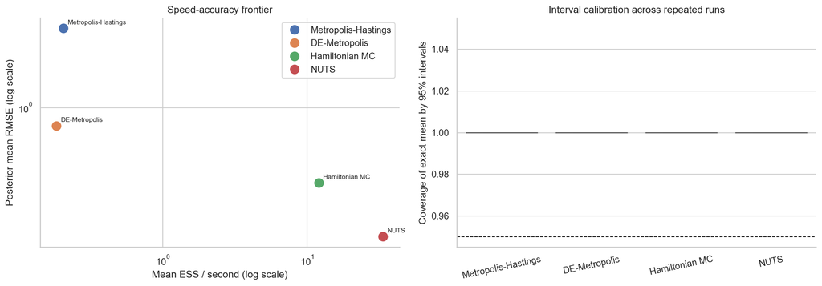

Exact-posterior accuracy on the p=50 correlated Gaussian target: higher ESS/sec and lower RMSE are preferable.

On the exact Gaussian target, **NUTS** achieves the smallest posterior-mean RMSE (0.2025), while **NUTS** also gives the best recovery of marginal posterior standard deviations (0.1642). By contrast, **DE-Metropolis** has the weakest variance recovery (9.8659), which shows why ESS/sec alone is not a sufficient notion of sampler quality.

## 7 Approximate Inference Comparison

The exact-Gaussian target also lets us compare approximate inference methods to exact samplers. Here we add mean-field ADVI and full-rank ADVI. Because these methods optimize a variational objective rather than generate Markov chains, runtime and posterior accuracy are more appropriate comparison metrics than r-hat.

```python
approximation_rows = []

for replicate, seed in enumerate(REFERENCE_SEEDS, start=1):
    for approximation_name in APPROXIMATION_ORDER:
        idata, metrics = run_model_with_approximation(
            model=reference_model,
            approximation_name=approximation_name,
            approx_config=APPROXIMATION_CONFIG,
            seed=seed,
        )
        accuracy_metrics = summarize_exact_gaussian_accuracy(
            idata,
            exact_mean=reference_exact_mean,
            exact_sd=reference_exact_sd,
        )
        approximation_rows.append(
            {
                "scenario": f"Exact Gaussian p={REFERENCE_DIM}",
                "scenario_short": "Exact Gaussian",
                "replicate": replicate,
                "seed": seed,
                "method": approximation_name,
                "method_family": "Approximate inference",
                **metrics,
                **accuracy_metrics,
            }
        )

approximation_results_df = pd.DataFrame(approximation_rows)
approximation_summary_df = (
    approximation_results_df.groupby(["method", "method_family"], observed=True)
    .agg(
        runtime_mean=("runtime_s", "mean"),
        runtime_low=("runtime_s", lambda x: empirical_interval(x)[0]),
        runtime_high=("runtime_s", lambda x: empirical_interval(x)[1]),
        mean_rmse_mean=("mean_rmse", "mean"),
        mean_rmse_low=("mean_rmse", lambda x: empirical_interval(x)[0]),
        mean_rmse_high=("mean_rmse", lambda x: empirical_interval(x)[1]),
        sd_rmse_mean=("sd_rmse", "mean"),
        sd_rmse_low=("sd_rmse", lambda x: empirical_interval(x)[0]),
        sd_rmse_high=("sd_rmse", lambda x: empirical_interval(x)[1]),
        coverage_mean=("coverage_95", "mean"),
        coverage_low=("coverage_95", lambda x: empirical_interval(x)[0]),
        coverage_high=("coverage_95", lambda x: empirical_interval(x)[1]),
        final_vi_loss_mean=("final_vi_loss", "mean"),
        final_vi_loss_low=("final_vi_loss", lambda x: empirical_interval(x)[0]),
        final_vi_loss_high=("final_vi_loss", lambda x: empirical_interval(x)[1]),
    )
    .reset_index()
)

approximation_display_df = approximation_summary_df.assign(
    **{
        "Final VI loss [95% interval]": [
            interval_string(row.final_vi_loss_mean, row.final_vi_loss_low, row.final_vi_loss_high, digits=1)
            for row in approximation_summary_df.itertuples()
        ]
    }
)[["method", "Final VI loss [95% interval]"]].rename(columns={"method": "Method"})

approximate_comparison_summary_df = pd.concat(
    [
        exact_reference_summary_df[
            [
                "method",
                "method_family",
                "runtime_mean",
                "runtime_low",
                "runtime_high",
                "mean_rmse_mean",
                "mean_rmse_low",
                "mean_rmse_high",
                "sd_rmse_mean",
                "sd_rmse_low",
                "sd_rmse_high",
                "coverage_mean",
                "coverage_low",
                "coverage_high",
            ]
        ],
        approximation_summary_df[
            [
                "method",
                "method_family",
                "runtime_mean",
                "runtime_low",
                "runtime_high",
                "mean_rmse_mean",
                "mean_rmse_low",
                "mean_rmse_high",
                "sd_rmse_mean",
                "sd_rmse_low",
                "sd_rmse_high",
                "coverage_mean",
                "coverage_low",
                "coverage_high",
            ]
        ],
    ],
    ignore_index=True,
)

approximate_comparison_display_df = approximate_comparison_summary_df.assign(
    **{
        "Runtime mean [95% interval]": [
            interval_string(row.runtime_mean, row.runtime_low, row.runtime_high, digits=2)
            for row in approximate_comparison_summary_df.itertuples()
        ],
        "Posterior mean RMSE [95% interval]": [
            interval_string(row.mean_rmse_mean, row.mean_rmse_low, row.mean_rmse_high, digits=4)
            for row in approximate_comparison_summary_df.itertuples()
        ],
        "Posterior sd RMSE [95% interval]": [
            interval_string(row.sd_rmse_mean, row.sd_rmse_low, row.sd_rmse_high, digits=4)
            for row in approximate_comparison_summary_df.itertuples()
        ],
        "95% mean coverage [95% interval]": [
            interval_string(row.coverage_mean, row.coverage_low, row.coverage_high, digits=3)
            for row in approximate_comparison_summary_df.itertuples()
        ],
    }
)[
    [
        "method",
        "method_family",
        "Runtime mean [95% interval]",
        "Posterior mean RMSE [95% interval]",
        "Posterior sd RMSE [95% interval]",
        "95% mean coverage [95% interval]",
    ]
].rename(columns={"method": "Method", "method_family": "Family"})

approximate_comparison_results_df = pd.concat(
    [
        reference_results_df.rename(columns={"sampler": "method"}).assign(method_family="Exact MCMC")[
            ["method", "method_family", "coverage_95"]
        ],
        approximation_results_df[["method", "method_family", "coverage_95"]],
    ],
    ignore_index=True,
)
```

| Method | Family | Runtime mean [95% interval] | Posterior mean RMSE [95% interval] | Posterior sd RMSE [95% interval] | 95% mean coverage [95% interval] |
| --- | --- | --- | --- | --- | --- |
| Metropolis-Hastings | Exact MCMC | 148.52 [18.89, 260.30] | 2.6596 [2.0108, 3.6122] | 1.6991 [1.5786, 1.8214] | 1.000 [1.000, 1.000] |
| DE-Metropolis | Exact MCMC | 173.16 [26.61, 261.96] | 0.7951 [0.5898, 0.9715] | 9.8659 [9.5175, 10.3712] | 1.000 [1.000, 1.000] |
| Hamiltonian MC | Exact MCMC | 180.12 [33.83, 268.83] | 0.3931 [0.3088, 0.4856] | 0.1833 [0.1553, 0.2097] | 1.000 [1.000, 1.000] |
| NUTS | Exact MCMC | 165.02 [40.08, 274.38] | 0.2025 [0.1675, 0.2851] | 0.1642 [0.1411, 0.1791] | 1.000 [1.000, 1.000] |
| Full-rank ADVI | Approximate inference | 85.18 [38.52, 257.50] | 0.0470 [0.0388, 0.0551] | 9.3716 [9.3607, 9.3780] | 1.000 [1.000, 1.000] |
| Mean-field ADVI | Approximate inference | 92.90 [32.20, 293.15] | 0.0349 [0.0297, 0.0412] | 10.1655 [10.1583, 10.1728] | 1.000 [1.000, 1.000] |

| Method | Final VI loss [95% interval] |
| --- | --- |
| Full-rank ADVI | 25.0 [21.7, 27.7] |
| Mean-field ADVI | 40.5 [30.7, 54.5] |

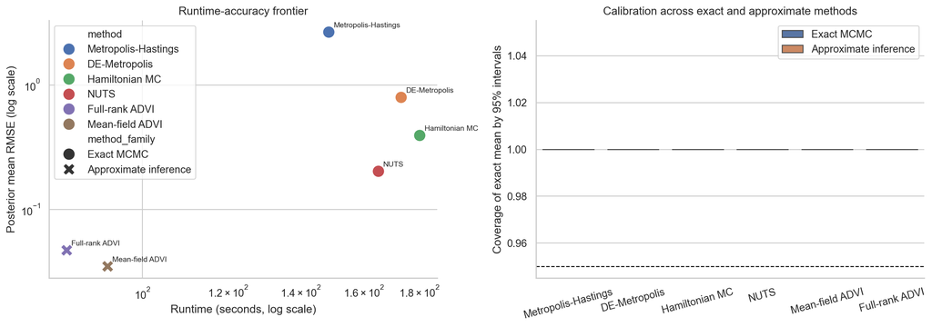

Approximate inference versus exact samplers on the known Gaussian target.

Within the variational family, **Mean-field ADVI** gives the smallest posterior-mean RMSE (0.0349), and **Full-rank ADVI** is the fastest approximation (85.18s on average). Within that same family, **Full-rank ADVI** gives the best variance recovery (9.3716), but both ADVI variants remain much weaker on posterior standard deviations than the best exact methods: the strongest exact mean estimator is **NUTS** (mean RMSE 0.2025), while **NUTS** gives the smallest sd RMSE (0.1642).

The results show an asymmetric tradeoff. The ADVI methods produce fast, low-error posterior mean estimates on this Gaussian target, but they perform poorly in recovering posterior uncertainty. This makes them useful for quick posterior screening, initialization, or rough effect ranking, while exact samplers remain the safer choice for final uncertainty reporting.

## 8 Budget-Response Curves

### 8.1 Budget-response on the exact Gaussian target

A single computational budget can obscure important behavior. Some methods improve steadily as more computation is allocated, while others plateau quickly or remain biased even when optimization is extended. To study this directly, we compare short, medium, and long budgets on the same exact Gaussian target for NUTS, mean-field ADVI, and full-rank ADVI.

```python
budget_rows = []

for replicate, seed in enumerate(BUDGET_SEEDS, start=1):
    for budget_label in BUDGET_LEVEL_ORDER:
        idata, metrics = run_model_with_sampler(
            model=reference_model,
            sampler_name="NUTS",
            summary_vars=["theta"],
            sample_config=BUDGET_MCMC_CONFIGS[budget_label],
            seed=seed,
        )
        accuracy_metrics = summarize_exact_gaussian_accuracy(
            idata,
            exact_mean=reference_exact_mean,
            exact_sd=reference_exact_sd,
        )
        budget_rows.append(
            {
                "replicate": replicate,
                "seed": seed,
                "budget": budget_label,
                "budget_index": BUDGET_LEVEL_ORDER.index(budget_label) + 1,
                "method": "NUTS",
                "method_family": "Exact MCMC",
                **metrics,
                **accuracy_metrics,
            }
        )

        for approximation_name in APPROXIMATION_ORDER:
            idata, metrics = run_model_with_approximation(
                model=reference_model,
                approximation_name=approximation_name,
                approx_config=BUDGET_APPROXIMATION_CONFIGS[budget_label],
                seed=seed,
            )
            accuracy_metrics = summarize_exact_gaussian_accuracy(
                idata,
                exact_mean=reference_exact_mean,
                exact_sd=reference_exact_sd,
            )
            budget_rows.append(
                {
                    "replicate": replicate,
                    "seed": seed,
                    "budget": budget_label,
                    "budget_index": BUDGET_LEVEL_ORDER.index(budget_label) + 1,
                    "method": approximation_name,
                    "method_family": "Approximate inference",
                    **metrics,
                    **accuracy_metrics,
                }
            )

budget_results_df = pd.DataFrame(budget_rows)
budget_results_df["method"] = pd.Categorical(
    budget_results_df["method"],
    categories=BUDGET_METHODS,
    ordered=True,
)
budget_results_df["budget"] = pd.Categorical(
    budget_results_df["budget"],
    categories=BUDGET_LEVEL_ORDER,
    ordered=True,
)

budget_summary_df = (
    budget_results_df.groupby(["method", "method_family", "budget", "budget_index"], observed=True)
    .agg(
        runtime_mean=("runtime_s", "mean"),
        runtime_low=("runtime_s", lambda x: empirical_interval(x)[0]),
        runtime_high=("runtime_s", lambda x: empirical_interval(x)[1]),
        mean_rmse_mean=("mean_rmse", "mean"),
        mean_rmse_low=("mean_rmse", lambda x: empirical_interval(x)[0]),
        mean_rmse_high=("mean_rmse", lambda x: empirical_interval(x)[1]),
        sd_rmse_mean=("sd_rmse", "mean"),
        sd_rmse_low=("sd_rmse", lambda x: empirical_interval(x)[0]),
        sd_rmse_high=("sd_rmse", lambda x: empirical_interval(x)[1]),
        coverage_mean=("coverage_95", "mean"),
        coverage_low=("coverage_95", lambda x: empirical_interval(x)[0]),
        coverage_high=("coverage_95", lambda x: empirical_interval(x)[1]),
    )
    .reset_index()
    .sort_values(["method", "budget_index"])
)

budget_display_df = budget_summary_df.assign(
    **{
        "Runtime mean [95% interval]": [
            interval_string(row.runtime_mean, row.runtime_low, row.runtime_high, digits=2)
            for row in budget_summary_df.itertuples()
        ],
        "Posterior mean RMSE [95% interval]": [
            interval_string(row.mean_rmse_mean, row.mean_rmse_low, row.mean_rmse_high, digits=4)
            for row in budget_summary_df.itertuples()
        ],
        "Posterior sd RMSE [95% interval]": [
            interval_string(row.sd_rmse_mean, row.sd_rmse_low, row.sd_rmse_high, digits=4)
            for row in budget_summary_df.itertuples()
        ],
        "95% mean coverage [95% interval]": [
            interval_string(row.coverage_mean, row.coverage_low, row.coverage_high, digits=3)
            for row in budget_summary_df.itertuples()
        ],
    }
)[
    [
        "method",
        "budget",
        "Runtime mean [95% interval]",
        "Posterior mean RMSE [95% interval]",
        "Posterior sd RMSE [95% interval]",
        "95% mean coverage [95% interval]",
    ]
].rename(columns={"method": "Method", "budget": "Budget"})
```

| Method | Budget | Runtime mean [95% interval] | Posterior mean RMSE [95% interval] | Posterior sd RMSE [95% interval] | 95% mean coverage [95% interval] |
| --- | --- | --- | --- | --- | --- |
| NUTS | Short | 71.94 [30.45, 113.73] | 0.3986 [0.3247, 0.4684] | 0.4150 [0.3602, 0.4649] | 1.000 [1.000, 1.000] |
| NUTS | Medium | 53.70 [21.85, 110.29] | 0.3203 [0.2232, 0.4270] | 0.2680 [0.2350, 0.2848] | 1.000 [1.000, 1.000] |
| NUTS | Long | 39.21 [37.03, 42.84] | 0.1877 [0.1261, 0.2276] | 0.1595 [0.1383, 0.1704] | 1.000 [1.000, 1.000] |
| Mean-field ADVI | Short | 96.73 [34.35, 159.16] | 0.0132 [0.0129, 0.0138] | 11.5650 [11.5635, 11.5666] | 1.000 [1.000, 1.000] |
| Mean-field ADVI | Medium | 86.37 [45.33, 156.19] | 0.0196 [0.0182, 0.0211] | 11.3037 [11.3016, 11.3056] | 1.000 [1.000, 1.000] |
| Mean-field ADVI | Long | 63.60 [46.20, 102.64] | 0.0389 [0.0360, 0.0414] | 10.1629 [10.1575, 10.1705] | 1.000 [1.000, 1.000] |
| Full-rank ADVI | Short | 95.25 [56.08, 143.72] | 0.0240 [0.0230, 0.0249] | 10.9390 [10.9364, 10.9424] | 1.000 [1.000, 1.000] |
| Full-rank ADVI | Medium | 46.13 [30.21, 68.99] | 0.0304 [0.0281, 0.0321] | 10.6429 [10.6404, 10.6474] | 1.000 [1.000, 1.000] |
| Full-rank ADVI | Long | 44.33 [40.77, 48.96] | 0.0517 [0.0471, 0.0539] | 9.3636 [9.3577, 9.3708] | 1.000 [1.000, 1.000] |

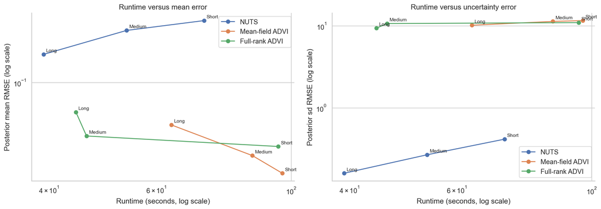

Budget-response curves on the exact Gaussian target.

Across increasing budgets, **Mean-field ADVI** achieves the smallest long-budget posterior-mean RMSE (0.0389), while **NUTS** gives the best long-budget posterior-sd RMSE (0.1595). For **NUTS**, posterior-mean RMSE drops from 0.3986 at the short budget to 0.1877 at the long budget, and posterior-sd RMSE drops from 0.4150 to 0.1595. By contrast, **Mean-field ADVI** stays extremely poor on uncertainty recovery (11.5650 to 10.1629), while **Full-rank ADVI** improves only modestly on that axis (10.9390 to 9.3636).

NUTS benefits from added compute on both mean and uncertainty error, whereas the variational methods reach very strong posterior means quickly but plateau at much poorer variance recovery. This provides a more substantive conclusion than a single-budget win table.

### 8.2 Budget-response on harder applied targets and funnel-like geometries

The exact-Gaussian budget-response study above evaluates runtime against posterior accuracy because the Gaussian target has known posterior moments. For the harder applied models and Neal’s Funnel, no analytic posterior is available, so this subsection focuses instead on efficiency and convergence diagnostics. We run the full MCMC sampler portfolio over the same short, medium, and long budget grid used above, keeping the number of chains fixed and varying only the amount of tuning and posterior sampling. This design tests whether additional computation improves effective sampling and reliability, and whether difficult posterior geometry can be resolved by longer chains alone. We use hierarchical regression, zero-inflated count regression, and Neal’s Funnel to represent increasingly challenging posterior structures.

```python
# Run the raw full-sampler budget-response experiments on harder targets.
# Set to False after the experiments have already been run and the raw CSV has been saved.
RUN_HARD_BUDGET = True
HARD_BUDGET_RAW_PATH = "hard_budget_results_raw.csv"

HARD_BUDGET_SEEDS = BUDGET_SEEDS[:2]

HARD_BUDGET_TARGETS = {
    "Hierarchical regression": {
        "target_short": "Hierarchical",
        "target_family": "Hard applied",
        "builder": build_hierarchical_model,
        "summary_vars": scenarios["Hierarchical regression"].summary_vars,
    },
    "Zero-inflated count regression": {
        "target_short": "Zero-inflated count",
        "target_family": "Hard applied",
        "builder": build_zip_model,
        "summary_vars": scenarios["Zero-inflated count regression"].summary_vars,
    },
    "Neal's Funnel": {
        "target_short": "Funnel",
        "target_family": "Geometry stress test",
        "builder": build_funnel_model,
        "summary_vars": ["z", "x"],
    },
}

HARD_BUDGET_TARGET_ORDER = list(HARD_BUDGET_TARGETS.keys())
HARD_BUDGET_SAMPLERS = sampler_order


def failed_hard_budget_row(
    target_name,
    target_info,
    sampler_name,
    budget_label,
    replicate,
    seed,
    error_message,
):
    return {
        "target": target_name,
        "target_short": target_info["target_short"],
        "target_family": target_info["target_family"],
        "replicate": replicate,
        "seed": seed,
        "budget": budget_label,
        "budget_index": BUDGET_LEVEL_ORDER.index(budget_label) + 1,
        "sampler": sampler_name,
        "sampler_family": sampler_specs[sampler_name]["family"],
        "uses_gradients": sampler_specs[sampler_name]["gradients"],
        "runtime_s": np.nan,
        "peak_mem_mib": np.nan,
        "median_ess_bulk": np.nan,
        "min_ess_bulk": np.nan,
        "median_ess_tail": np.nan,
        "ess_per_second": np.nan,
        "tail_ess_per_second": np.nan,
        "max_rhat": np.nan,
        "divergences": np.nan,
        "mean_accept_stat": np.nan,
        "mean_n_steps": np.nan,
        "mean_step_size": np.nan,
        "mean_tree_depth": np.nan,
        "max_treedepth_rate": np.nan,
        "mean_bfmi": np.nan,
        "reliable_run": False,
        "failed_run": True,
        "error_message": str(error_message),
    }


def normalize_failed_flag(series):
    return series.astype(str).str.lower().isin(["true", "1", "yes"])


def completed_hard_budget_keys(df):
    if df.empty:
        return set()

    if "failed_run" not in df.columns:
        return set()

    working = df.copy()
    working["failed_run_bool"] = normalize_failed_flag(working["failed_run"])

    completed = working.loc[~working["failed_run_bool"]].copy()

    if completed.empty:
        return set()

    return set(
        zip(
            completed["target"].astype(str),
            completed["sampler"].astype(str),
            completed["budget"].astype(str),
            completed["seed"].astype(int),
        )
    )


def all_hard_budget_jobs():
    jobs = []

    for target_name in HARD_BUDGET_TARGET_ORDER:
        for replicate, seed in enumerate(HARD_BUDGET_SEEDS, start=1):
            for budget_label in BUDGET_LEVEL_ORDER:
                for sampler_name in HARD_BUDGET_SAMPLERS:
                    key = (
                        target_name,
                        sampler_name,
                        budget_label,
                        int(seed),
                    )

                    jobs.append(
                        {
                            "key": key,
                            "target_name": target_name,
                            "replicate": replicate,
                            "seed": seed,
                            "budget_label": budget_label,
                            "sampler_name": sampler_name,
                        }
                    )

    return jobs


if os.path.exists(HARD_BUDGET_RAW_PATH):
    hard_budget_results_df = pd.read_csv(HARD_BUDGET_RAW_PATH)
else:
    hard_budget_results_df = pd.DataFrame()

if RUN_HARD_BUDGET:
    hard_budget_rows = (
        hard_budget_results_df.to_dict("records")
        if not hard_budget_results_df.empty
        else []
    )

    done_keys = completed_hard_budget_keys(hard_budget_results_df)
    planned_jobs = all_hard_budget_jobs()
    remaining_jobs = [job for job in planned_jobs if job["key"] not in done_keys]

    print(f"Planned jobs: {len(planned_jobs)}")
    print(f"Completed jobs found in CSV: {len(done_keys)}")
    print(f"Remaining jobs to run: {len(remaining_jobs)}")

    for run_id, job in enumerate(remaining_jobs, start=1):
        target_name = job["target_name"]
        replicate = job["replicate"]
        seed = job["seed"]
        budget_label = job["budget_label"]
        sampler_name = job["sampler_name"]
        target_info = HARD_BUDGET_TARGETS[target_name]

        print(
            f"[{run_id}/{len(remaining_jobs)}] "
            f"{target_name} | {sampler_name} | {budget_label} | seed={seed}"
        )

        try:
            model = target_info["builder"]()

            _, metrics = run_model_with_sampler(
                model=model,
                sampler_name=sampler_name,
                summary_vars=target_info["summary_vars"],
                sample_config=BUDGET_MCMC_CONFIGS[budget_label],
                seed=seed,
            )

            row = {
                "target": target_name,
                "target_short": target_info["target_short"],
                "target_family": target_info["target_family"],
                "replicate": replicate,
                "seed": seed,
                "budget": budget_label,
                "budget_index": BUDGET_LEVEL_ORDER.index(budget_label) + 1,
                "sampler": sampler_name,
                "sampler_family": sampler_specs[sampler_name]["family"],
                "uses_gradients": sampler_specs[sampler_name]["gradients"],
                "failed_run": False,
                "error_message": "",
                **metrics,
            }

        except Exception as err:
            row = failed_hard_budget_row(
                target_name=target_name,
                target_info=target_info,
                sampler_name=sampler_name,
                budget_label=budget_label,
                replicate=replicate,
                seed=seed,
                error_message=err,
            )

        hard_budget_rows.append(row)
        hard_budget_results_df = pd.DataFrame(hard_budget_rows)
        hard_budget_results_df.to_csv(HARD_BUDGET_RAW_PATH, index=False)

else:
    hard_budget_results_df = pd.read_csv(HARD_BUDGET_RAW_PATH)

hard_budget_results_df.head()
```

[output not shown]

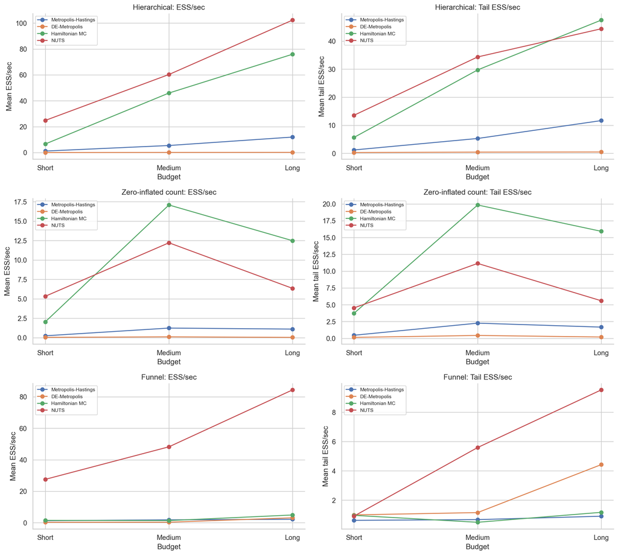

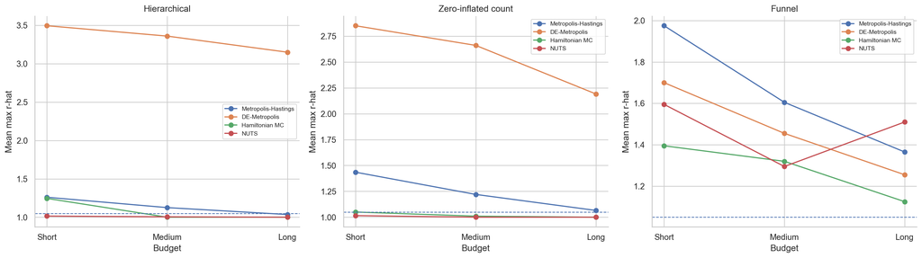

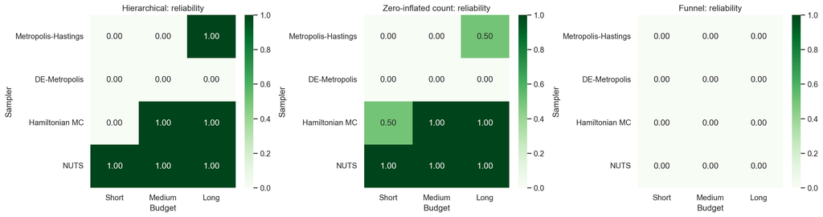

Neal’s Funnel behaves differently from the two applied targets. Although NUTS has the highest ESS/sec and tail ESS/sec on the funnel target, all samplers fail the reliability criterion across the full budget grid. The max r-hat values remain above the convergence threshold, so the high NUTS efficiency should not be interpreted as successful posterior exploration. Instead, the result suggests that funnel-like geometry is not solved by longer chains alone.

## 9 Hierarchical Parameterization Study

One important limitation of any sampler benchmark is that performance can be driven as much by parameterization as by the algorithm itself. To study that effect directly, we compare centered and non-centered versions of the hierarchical regression model under the two gradient-based samplers.

```python
parameterization_builders = {
    "Centered": build_hierarchical_model,
    "Non-centered": build_noncentered_hierarchical_model,
}
parameterization_scenarios = [
    "Centered hierarchical regression",
    "Non-centered hierarchical regression",
]
parameterization_rows = []
parameterization_example_traces = {}

for parameterization_name, builder in parameterization_builders.items():
    model = builder()
    for replicate, seed in enumerate(PARAMETERIZATION_SEEDS, start=1):
        for sampler_name in PARAMETERIZATION_SAMPLERS:
            idata, metrics = run_model_with_sampler(
                model=model,
                sampler_name=sampler_name,
                summary_vars=["mu_a", "tau_a", "a", "beta", "sigma"],
                sample_config=REPEATED_CONFIG,
                seed=seed,
            )
            parameterization_rows.append(
                {
                    "scenario": f"{parameterization_name} hierarchical regression",
                    "scenario_short": parameterization_name,
                    "parameterization": parameterization_name,
                    "replicate": replicate,
                    "seed": seed,
                    "sampler": sampler_name,
                    **metrics,
                }
            )
            if replicate == 1:
                parameterization_example_traces[(parameterization_name, sampler_name)] = idata

parameterization_results_df = finalize_results_df(pd.DataFrame(parameterization_rows), parameterization_scenarios)
parameterization_summary_df = summarize_repeated_block(parameterization_results_df, parameterization_scenarios)

parameterization_diag_df = (
    parameterization_results_df.groupby(["scenario", "scenario_short", "sampler"], observed=True)
    .agg(
        bfmi_mean=("mean_bfmi", "mean"),
        bfmi_low=("mean_bfmi", lambda x: empirical_interval(x)[0]),
        bfmi_high=("mean_bfmi", lambda x: empirical_interval(x)[1]),
        tail_ess_mean=("tail_ess_per_second", "mean"),
        tail_ess_low=("tail_ess_per_second", lambda x: empirical_interval(x)[0]),
        tail_ess_high=("tail_ess_per_second", lambda x: empirical_interval(x)[1]),
        accept_mean=("mean_accept_stat", "mean"),
    )
    .reset_index()
)

parameterization_merged_df = parameterization_summary_df.merge(
    parameterization_diag_df,
    on=["scenario", "scenario_short", "sampler"],
    how="left",
)

parameterization_display_df = parameterization_merged_df.assign(
    **{
        "ESS/sec mean [95% interval]": [
            interval_string(row.ess_mean, row.ess_low, row.ess_high, digits=1)
            for row in parameterization_merged_df.itertuples()
        ],
        "Tail ESS/sec mean [95% interval]": [
            interval_string(row.tail_ess_mean, row.tail_ess_low, row.tail_ess_high, digits=1)
            for row in parameterization_merged_df.itertuples()
        ],
        "Mean BFMI [95% interval]": [
            interval_string(row.bfmi_mean, row.bfmi_low, row.bfmi_high, digits=3)
            for row in parameterization_merged_df.itertuples()
        ],
        "Mean accept stat": parameterization_merged_df["accept_mean"].round(3),
        "Mean max r-hat": parameterization_merged_df["rhat_mean"].round(3),
        "Reliability rate": parameterization_merged_df["reliability_rate"].round(2),
    }
)[
    [
        "scenario_short",
        "sampler",
        "ESS/sec mean [95% interval]",
        "Tail ESS/sec mean [95% interval]",
        "Mean BFMI [95% interval]",
        "Mean accept stat",
        "Mean max r-hat",
        "Reliability rate",
    ]
].rename(columns={"scenario_short": "Parameterization", "sampler": "Sampler"})
```

| Parameterization | Sampler | ESS/sec mean [95% interval] | Tail ESS/sec mean [95% interval] | Mean BFMI [95% interval] | Mean accept stat | Mean max r-hat | Reliability rate |
| --- | --- | --- | --- | --- | --- | --- | --- |
| Centered | Hamiltonian MC | 100.0 [72.0, 118.1] | 71.0 [52.1, 85.1] | 1.020 [1.004, 1.054] | 1 | 1 | 1 |
| Centered | NUTS | 106.8 [17.8, 160.6] | 50.2 [8.3, 75.1] | 1.013 [0.991, 1.046] | 1 | 1 | 1 |
| Non-centered | Hamiltonian MC | 147.4 [100.9, 203.3] | 27.5 [20.3, 36.7] | 0.737 [0.695, 0.769] | 1 | 1 | 1 |
| Non-centered | NUTS | 121.7 [89.3, 169.4] | 55.6 [42.3, 74.0] | 0.746 [0.719, 0.778] | 1 | 1 | 1 |

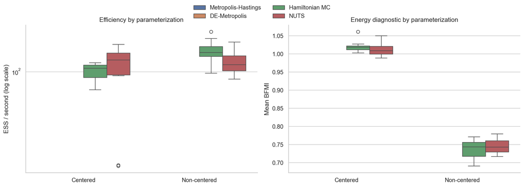

Repeated-run efficiency and BFMI under centered versus non-centered hierarchical parameterizations.

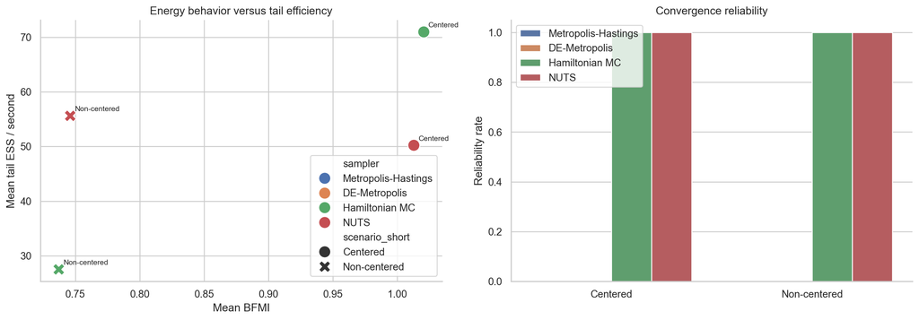

CSV-based geometry diagnostics for centered versus non-centered hierarchical parameterizations.

Parameterization effects are sampler-specific rather than one-directional in this model. For **NUTS**, the non-centered form is stronger on mean ESS/sec (121.7 versus 106.8), whereas **Hamiltonian MC** gains raw ESS/sec under the non-centered form (147.4 versus 100.0). Both parameterizations remain fully reliable here, which means geometry can matter even when standard convergence flags stay quiet.

This section makes the benchmark more informative for real modeling practice. In this example, the non-centered form is not universally better: it improves raw ESS/sec for both static HMC and NUTS, but the centered form keeps BFMI healthier overall. That is exactly why parameterization belongs in a serious sampler comparison instead of being treated as a nuisance detail.

## 10 Neal’s Funnel Geometry Stress Test

Applied benchmarks are useful, but they do not always expose the geometric pathologies that make one sampler fundamentally different from another. Neal’s Funnel is a classic test case for that reason.

The model is

$$z \sim \mathcal{N}(0, 3^2), \qquad x_i \mid z \sim \mathcal{N}(0, \exp(z/2))$$

When $z$ is very negative, the funnel neck becomes extremely tight. Random-walk proposals can struggle badly, while dynamic HMC methods are designed to adapt much better.

```python
funnel_model = build_funnel_model()
funnel_rows = []
funnel_example_traces = {}

for replicate, seed in enumerate(FUNNEL_SEEDS, start=1):
    for sampler_name in sampler_order:
        idata, metrics = run_model_with_sampler(
            model=funnel_model,
            sampler_name=sampler_name,
            summary_vars=["z", "x"],
            sample_config=FUNNEL_CONFIG,
            seed=seed,
        )
        funnel_rows.append(
            {
                "scenario": "Neal's Funnel",
                "scenario_short": "Funnel",
                "replicate": replicate,
                "seed": seed,
                "sampler": sampler_name,
                **metrics,
            }
        )
        if replicate == 1:
            funnel_example_traces[sampler_name] = idata

funnel_results_df = finalize_results_df(pd.DataFrame(funnel_rows))
funnel_summary_df = summarize_repeated_block(funnel_results_df, ["Neal's Funnel"])
funnel_display_df = funnel_summary_df.assign(
    **{
        "ESS/sec mean [95% interval]": [
            interval_string(row.ess_mean, row.ess_low, row.ess_high, digits=1)
            for row in funnel_summary_df.itertuples()
        ],
        "Runtime mean [95% interval]": [
            interval_string(row.runtime_mean, row.runtime_low, row.runtime_high, digits=2)
            for row in funnel_summary_df.itertuples()
        ],
        "Mean max r-hat": funnel_summary_df["rhat_mean"].round(3),
        "Reliability rate": funnel_summary_df["reliability_rate"].round(2),
        "Pr(best ESS/s)": funnel_summary_df["pr_best_ess"].round(2),
    }
)[
    [
        "sampler",
        "ESS/sec mean [95% interval]",
        "Runtime mean [95% interval]",
        "Mean max r-hat",
        "Reliability rate",
        "Pr(best ESS/s)",
    ]
].rename(columns={"sampler": "Sampler"})

funnel_pairwise_ess = pairwise_probability_matrix(
    funnel_results_df,
    metric="ess_per_second",
    higher_is_better=True,
)

funnel_hmc_diag_df = (
    funnel_results_df.loc[funnel_results_df["sampler"].isin(PARAMETERIZATION_SAMPLERS)]
    .groupby("sampler", observed=True)
    .agg(
        tail_ess_mean=("tail_ess_per_second", "mean"),
        tail_ess_low=("tail_ess_per_second", lambda x: empirical_interval(x)[0]),
        tail_ess_high=("tail_ess_per_second", lambda x: empirical_interval(x)[1]),
        bfmi_mean=("mean_bfmi", "mean"),
        bfmi_low=("mean_bfmi", lambda x: empirical_interval(x)[0]),
        bfmi_high=("mean_bfmi", lambda x: empirical_interval(x)[1]),
        accept_mean=("mean_accept_stat", "mean"),
        n_steps_mean=("mean_n_steps", "mean"),
        tree_depth_mean=("mean_tree_depth", "mean"),
        max_treedepth_rate_mean=("max_treedepth_rate", "mean"),
    )
    .reset_index()
)

funnel_hmc_display_df = funnel_hmc_diag_df.assign(
    **{
        "Tail ESS/sec mean [95% interval]": [
            interval_string(row.tail_ess_mean, row.tail_ess_low, row.tail_ess_high, digits=1)
            for row in funnel_hmc_diag_df.itertuples()
        ],
        "Mean BFMI [95% interval]": [
            interval_string(row.bfmi_mean, row.bfmi_low, row.bfmi_high, digits=3)
            for row in funnel_hmc_diag_df.itertuples()
        ],
        "Mean accept stat": funnel_hmc_diag_df["accept_mean"].round(3),
        "Mean n_steps": funnel_hmc_diag_df["n_steps_mean"].round(1),
        "Mean tree depth": [
            f"{value:.2f}" if np.isfinite(value) else "NA"
            for value in funnel_hmc_diag_df["tree_depth_mean"].to_numpy(dtype=float)
        ],
        "Pr(max treedepth)": [
            f"{value:.2f}" if np.isfinite(value) else "NA"
            for value in funnel_hmc_diag_df["max_treedepth_rate_mean"].to_numpy(dtype=float)
        ],
    }
)[
    [
        "sampler",
        "Tail ESS/sec mean [95% interval]",
        "Mean BFMI [95% interval]",
        "Mean accept stat",
        "Mean n_steps",
        "Mean tree depth",
        "Pr(max treedepth)",
    ]
].rename(columns={"sampler": "Sampler"})
```

[output not shown]

| Sampler | Tail ESS/sec mean [95% interval] | Mean BFMI [95% interval] | Mean accept stat | Mean n_steps | Mean tree depth | Pr(max treedepth) |
| --- | --- | --- | --- | --- | --- | --- |
| Hamiltonian MC | 2.8 [0.7, 5.7] | 1.748 [1.062, 1.955] | 1 | 14 | NA | NA |
| NUTS | 8.6 [3.3, 19.3] | 0.103 [0.068, 0.157] | 1 | 50 | 4.18 | 0.00 |

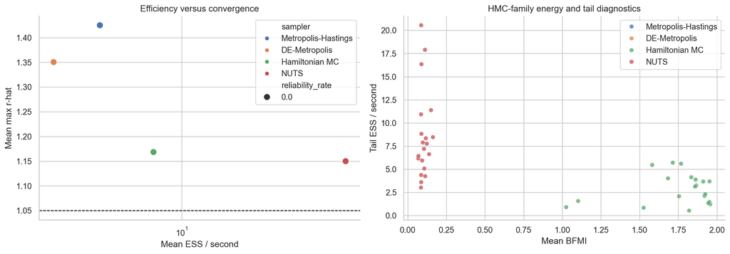

Neal’s Funnel stress diagnostics by sampler.

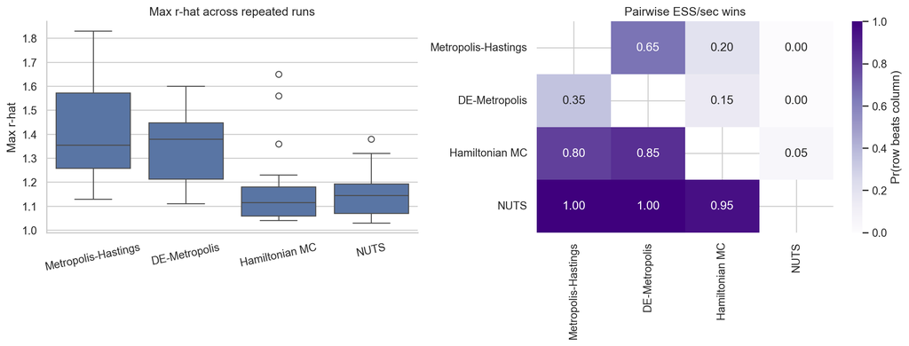

Repeated-seed diagnostics for Neal’s Funnel.

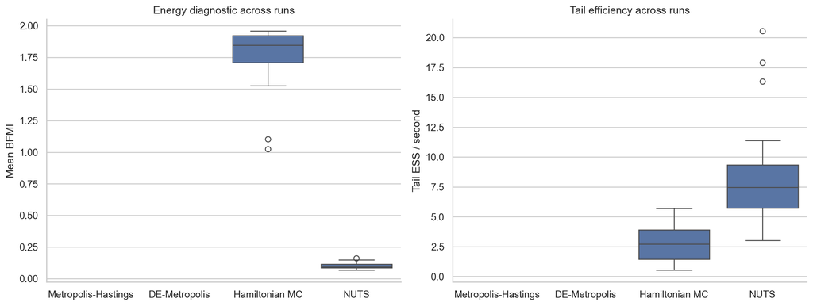

Richer HMC-family diagnostics on Neal’s Funnel.

On Neal’s Funnel, **NUTS** is the clear efficiency leader (68.8 ESS/sec versus 7.2 for Hamiltonian MC), but the richer diagnostics show that the geometry is still hostile: its mean BFMI is only 0.103 and its mean tree depth is 4.18. Thus, the funnel result is not merely a ranking table; it also shows why even the best-performing method remains under geometric stress.

Neal’s Funnel is where the geometric differences between samplers become impossible to ignore. In the applied battery, one might still be tempted to focus on runtime.

At the same time, the funnel results are a reminder that this is still a finite-budget benchmark. Even with four chains, 500 tuning iterations, and 1000 retained draws per chain, Neal’s Funnel remains demanding under the strict reliability threshold used here, while NUTS is clearly the strongest performer by repeated-run ESS/sec. The added BFMI, tail ESS, and tree-depth diagnostics also make the geometry story more mechanistic than a simple speed comparison.

## 11 Posterior Predictive Checks

Concretely, the *posterior predictive density* is

$$p(y_{\text{rep}} \mid y) \;=\; \int p(y_{\text{rep}} \mid \theta)\, p(\theta \mid y)\, d\theta,$$

so a single posterior predictive draw is obtained by first sampling $\theta \sim p(\theta \mid y)$ from the fitted posterior and then sampling $y_{\text{rep}} \sim p(y_{\text{rep}} \mid \theta)$ from the likelihood. Repeating this many times yields a sample from $p(y_{\text{rep}} \mid y)$, which is what `pm.sample_posterior_predictive` produces and what `az.plot_ppc` overlays against the observed $y$. The graphical PPC used here has a quantitative counterpart, the *Bayesian posterior predictive p-value* of Gelman, Meng & Stern (1996), $p_B = \Pr\bigl(T(y_{\text{rep}}, \theta) \geq T(y_{\text{obs}}, \theta) \,\big|\, y\bigr)$ for a chosen test statistic $T$. We retain the graphical version because the question of interest at this stage is whether the *whole shape* of the response distribution is covered by the replicates—shape mismatches that no single scalar $T$ would necessarily flag.

We run PPC on all five applied scenarios using the single-seed NUTS posteriors obtained in Section 4.

```python
ppc_idata_by_scenario = {}

for scenario_name in scenario_order:
    scenario = scenarios[scenario_name]
    model = portfolio_models[scenario_name]
    idata = portfolio_idatas[scenario_name]["NUTS"]
    with model:
        ppc = pm.sample_posterior_predictive(
            idata,
            random_seed=PORTFOLIO_SEED,
            progressbar=False,
        )
    idata.extend(ppc)
    ppc_idata_by_scenario[scenario_name] = idata
```

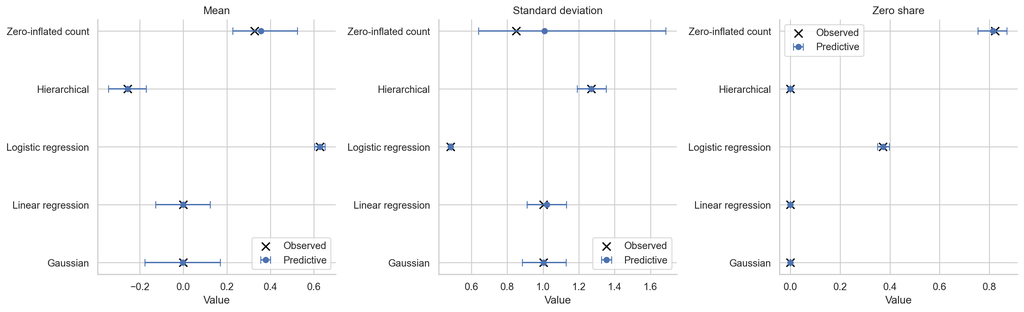

Posterior predictive checks for the five applied scenarios using NUTS. Points are observed summaries; intervals are posterior predictive 95% ranges.

## 12 Simulation-Based Calibration

PPC addressed the *model–data* half of inferential reliability. SBC addresses the *sampler* half: it asks whether the posterior samples produced by a given sampler are statistically consistent with the true posterior that the sampler is supposed to target, independent of any particular observed dataset. A biased sampler can pass both R-hat diagnostics and PPCs while still producing posterior samples that systematically misplace the true parameter—an error PPC cannot see because PPC never compares the posterior against a known ground truth, and an error r-hat cannot see because r-hat only measures agreement *between chains of the same sampler* rather than agreement with the true posterior. SBC addresses this blind spot by simulating ground truth from the prior itself and measuring where the true parameter lands within the sampler’s posterior samples. The algorithm is:

1. Draw a true parameter $\theta^{*}$ from the prior.
2. Simulate data $y$ from the likelihood given $\theta^{*}$.
3. Fit the model on $y$ and record posterior samples $\theta_{1}, \ldots, \theta_{M}$.
4. Compute the rank of $\theta^{*}$ within those samples.

Under a correctly specified pipeline those ranks are uniform on $[0, 1]$. Deviations diagnose specific failure modes:

- **U-shaped histogram**: the posterior is too narrow (the truth lands in the tails too often).
- **∩-shaped histogram**: the posterior is too wide.
- **Skewed histogram**: the posterior mean is biased.

We run SBC on two of the applied scenarios and on all four samplers in the portfolio (Metropolis-Hastings, DE-Metropolis, Hamiltonian MC, NUTS), producing a $4 \times 2$ design in which each cell is checked by thirty independent rounds. The Gaussian location model is the simplest continuous target and serves as a baseline that every reasonable sampler should pass; the hierarchical regression is the most structurally sensitive applied target and is where we expect sampler-level differences to surface first. Two scenarios (rather than all five applied scenarios) keeps the runtime bounded at $4 \times 2 \times 30 = 240$ posterior fits while still covering the easy–hard extremes of the portfolio, which is the same design choice used in the original SBC literature (Talts et al., 2018) where calibration is demonstrated on a small number of deliberately chosen representative targets rather than the full model catalog. For each round we use a reduced sampling budget of two chains, 200 tuning iterations, and 500 retained draws per chain.

```python
SBC_CONFIG = {
    "draws": 500,
    "tune": 200,
    "chains": SBC_CHAINS,
    "cores": SBC_CORES,
    "progressbar": False,
    "return_inferencedata": True,
    "compute_convergence_checks": False,
    "idata_kwargs": {"log_likelihood": False},
}
SBC_N_ROUNDS = 30
SBC_SCENARIOS = ["Gaussian location model", "Hierarchical regression"]
SBC_SAMPLERS = sampler_order
SBC_PARAMS = {
    "Gaussian location model": ["mu", "sigma"],
    "Hierarchical regression": ["mu_a", "tau_a", "beta", "sigma"],
}
SBC_SEEDS = {
    "Gaussian location model": [RANDOM_SEED + 3000 + i for i in range(SBC_N_ROUNDS)],
    "Hierarchical regression": [RANDOM_SEED + 3500 + i for i in range(SBC_N_ROUNDS)],
}


def build_gaussian_for_sbc(n_obs):
    coords = {"obs_id": np.arange(n_obs)}
    with pm.Model(coords=coords) as model:
        y_obs = pm.Data("y_obs", np.zeros(n_obs), dims="obs_id")
        mu = pm.Normal("mu", mu=0.0, sigma=1.5)
        sigma = pm.HalfNormal("sigma", sigma=1.0)
        pm.Normal("obs", mu=mu, sigma=sigma, observed=y_obs, dims="obs_id")
    return model


def build_hier_for_sbc(x_vals, group_idx_vals, group_labels_local):
    n_obs = len(x_vals)
    coords = {"obs_id": np.arange(n_obs), "group": group_labels_local}
    with pm.Model(coords=coords) as model:
        x = pm.Data("x", np.asarray(x_vals, dtype=float), dims="obs_id")
        group_idx = pm.Data("group_idx", np.asarray(group_idx_vals, dtype="int64"), dims="obs_id")
        y_obs = pm.Data("y_obs", np.zeros(n_obs), dims="obs_id")
        mu_a = pm.Normal("mu_a", mu=0.0, sigma=1.5)
        tau_a = pm.HalfNormal("tau_a", sigma=1.0)
        a = pm.Normal("a", mu=mu_a, sigma=tau_a, dims="group")
        beta = pm.Normal("beta", mu=0.0, sigma=1.0)
        sigma = pm.HalfNormal("sigma", sigma=1.0)
        mu = a[group_idx] + beta * x
        pm.Normal("obs", mu=mu, sigma=sigma, observed=y_obs, dims="obs_id")
    return model


sbc_models = {
    "Gaussian location model": build_gaussian_for_sbc(gaussian_y.shape[0]),
    "Hierarchical regression": build_hier_for_sbc(x_hier, hier_group_idx, hier_group_labels),
}


def sbc_one_round(scenario_name, seed, sampler_name="NUTS"):
    model = sbc_models[scenario_name]
    with model:
        prior = pm.sample_prior_predictive(draws=1, random_seed=seed)
    y_sim = np.asarray(prior.prior_predictive["obs"]).reshape(-1)
    theta_star = {
        name: float(np.asarray(prior.prior[name]).ravel()[0])
        for name in SBC_PARAMS[scenario_name]
    }
    with model:
        pm.set_data({"y_obs": y_sim})
        idata = pm.sample(
            step=sampler_specs[sampler_name]["factory"](),
            random_seed=seed,
            **SBC_CONFIG,
        )
    ranks = {}
    for param_name, theta in theta_star.items():
        posterior_vals = np.asarray(idata.posterior[param_name]).reshape(-1)
        ranks[param_name] = float((posterior_vals < theta).mean())
    return ranks
```

```python
sbc_rows = []
for scenario_name in SBC_SCENARIOS:
    for sampler_name in SBC_SAMPLERS:
        for round_idx, seed in enumerate(SBC_SEEDS[scenario_name]):
            ranks = sbc_one_round(scenario_name, seed, sampler_name=sampler_name)
            for param_name, rank_val in ranks.items():
                sbc_rows.append(
                    {
                        "scenario": scenario_name,
                        "scenario_short": scenarios[scenario_name].short_name,
                        "sampler": sampler_name,
                        "param": param_name,
                        "round": round_idx,
                        "seed": seed,
                        "rank": rank_val,
                    }
                )

sbc_results_df = pd.DataFrame(sbc_rows)
```

Each rank is the empirical quantile of the prior-drawn true value $\theta^{*}$ within the $M = 2 \times 500 = 1{,}000$ posterior samples produced by a given sampler from the simulated data. Under a calibrated sampler the collection of ranks across independent rounds is Uniform$(0, 1)$, so each bin of the histogram should contain approximately $N_{\text{rounds}} / N_{\text{bins}} = 30 / 10 = 3$ observations; this expected count is drawn as a red dashed line for reference. The uniform mean of $0.5$ and the uniform standard deviation of $\sqrt{1/12} \approx 0.289$ are the two numerical anchors used in the summary table at the end of the section. Each figure below shows one scenario; rows are samplers and columns are the parameters for which SBC ranks are tracked, so reading a single column top-to-bottom compares the four samplers on the same parameter, while reading a single row left-to-right checks whether one sampler is calibrated across all parameters of that scenario.

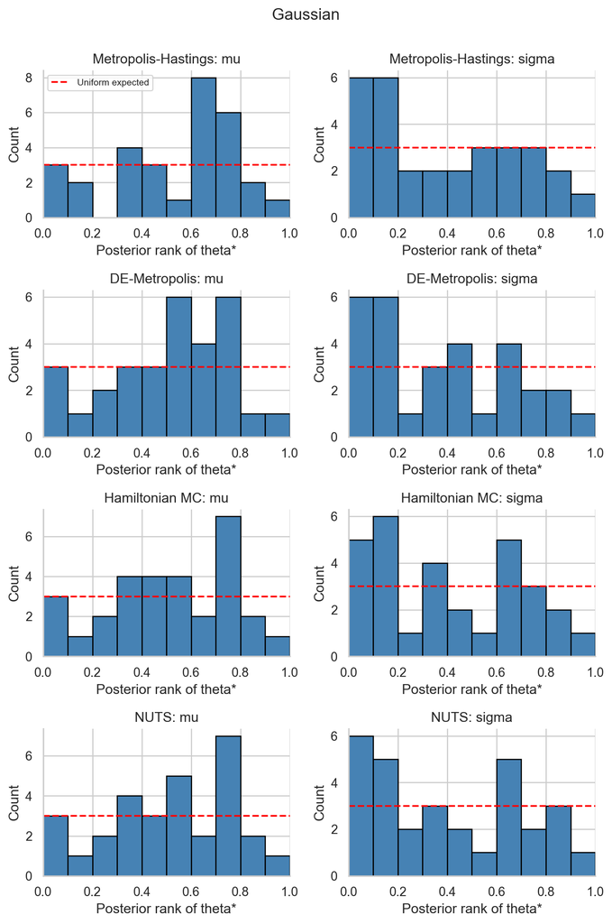

SBC rank histograms faceted by sampler (rows) and parameter (columns) for each scenario. Uniform distribution around the red dashed line indicates a calibrated sampler; systematic deviation indicates a miscalibrated posterior that r-hat and ESS cannot detect.

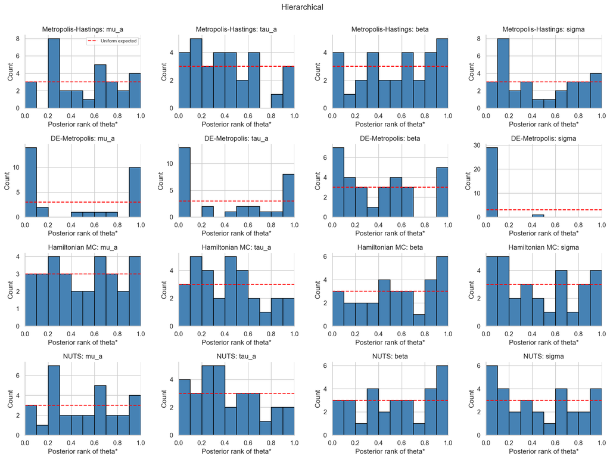

The two figures above expose a clear separation between scenarios and between samplers. In the Gaussian scenario all four samplers produce histograms that hover around the red uniform line with only the bin-to-bin noise expected at thirty rounds; no row shows a systematic U-shape, $\cap$-shape, or one-sided skew. In the Hierarchical scenario three of the four samplers (Metropolis-Hastings, Hamiltonian MC, and NUTS) remain close to uniform, but the DE-Metropolis row is visibly different: `mu_a` and `tau_a` show pronounced piles at both $0$ and $1$ with a hollow middle, `beta` shows a milder version of the same pattern, and `sigma` collapses into a single tall spike in the leftmost bin with essentially nothing to the right of $0.1$. These shapes are the diagnostic signatures listed earlier (U-shape and extreme left skew) and they are the first concrete, sampler-discriminating finding the SBC section is designed to produce. The numerical summary below converts these visual impressions into mean and standard-deviation deviations from the Uniform$(0,1)$ anchors of $0.5$ and $0.289$.

In addition to the visual histograms, we report a **Kolmogorov–Smirnov test** of each rank set against the Uniform$(0,1)$ reference. KS measures the largest vertical gap between the empirical CDF of the 30 ranks and the theoretical Uniform CDF $F(x) = x$, and returns a p-value for the null hypothesis “ranks are Uniform$(0,1)$.” A p-value below conventional thresholds (e.g. $0.05$) constitutes a quantitative rejection of calibration that complements the visual reading of the histograms.

| Scenario | Sampler | Parameter | Mean rank | SD of rank | Min rank | Max rank | KS p-value |
| --- | --- | --- | --- | --- | --- | --- | --- |
| Gaussian | Metropolis-Hastings | mu | 0.532 | 0.264 | 0.014 | 0.983 | 0.291 |
| Gaussian | Metropolis-Hastings | sigma | 0.393 | 0.3 | 0.001 | 0.951 | 0.0741 |
| Gaussian | DE-Metropolis | mu | 0.511 | 0.243 | 0.026 | 0.912 | 0.3852 |
| Gaussian | DE-Metropolis | sigma | 0.385 | 0.292 | 0.029 | 0.998 | 0.0617 |
| Gaussian | Hamiltonian MC | mu | 0.515 | 0.251 | 0.019 | 0.943 | 0.4483 |
| Gaussian | Hamiltonian MC | sigma | 0.408 | 0.308 | 0.015 | 0.996 | 0.1477 |
| Gaussian | NUTS | mu | 0.511 | 0.255 | 0.017 | 0.946 | 0.6254 |
| Gaussian | NUTS | sigma | 0.409 | 0.304 | 0.005 | 0.994 | 0.1715 |
| Hierarchical | Metropolis-Hastings | mu_a | 0.509 | 0.295 | 0.041 | 1 | 0.7719 |
| Hierarchical | Metropolis-Hastings | tau_a | 0.415 | 0.278 | 0 | 1 | 0.2747 |
| Hierarchical | Metropolis-Hastings | beta | 0.552 | 0.33 | 0 | 1 | 0.5431 |
| Hierarchical | Metropolis-Hastings | sigma | 0.454 | 0.336 | 0.029 | 1 | 0.2078 |
| Hierarchical | DE-Metropolis | mu_a | 0.419 | 0.46 | 0 | 1 | 0 |
| Hierarchical | DE-Metropolis | tau_a | 0.434 | 0.435 | 0 | 1 | 0.0001 |
| Hierarchical | DE-Metropolis | beta | 0.405 | 0.339 | 0 | 1 | 0.1381 |
| Hierarchical | DE-Metropolis | sigma | 0.018 | 0.081 | 0 | 0.44 | 0 |
| Hierarchical | Hamiltonian MC | mu_a | 0.5 | 0.299 | 0.041 | 0.986 | 0.953 |
| Hierarchical | Hamiltonian MC | tau_a | 0.423 | 0.272 | 0.036 | 1 | 0.2404 |
| Hierarchical | Hamiltonian MC | beta | 0.56 | 0.328 | 0.001 | 0.991 | 0.3212 |
| Hierarchical | Hamiltonian MC | sigma | 0.456 | 0.325 | 0.01 | 0.999 | 0.3583 |
| Hierarchical | NUTS | mu_a | 0.504 | 0.292 | 0.039 | 0.968 | 0.9003 |
| Hierarchical | NUTS | tau_a | 0.424 | 0.278 | 0.032 | 1 | 0.2629 |
| Hierarchical | NUTS | beta | 0.556 | 0.33 | 0.002 | 0.993 | 0.3607 |
| Hierarchical | NUTS | sigma | 0.456 | 0.328 | 0.018 | 1 | 0.2459 |

### 12.2 Hierarchical scenario: DE-Metropolis fails SBC

DE-Metropolis is the exception, with clear evidence of calibration failure:

- **`sigma` collapses to the leftmost bin.** The mean rank is $0.018$ and the standard deviation is $0.081$, against uniform anchors of $0.5$ and $0.289$, and the KS p-value rounds to $0.0000$ (well below $10^{-10}$). The histogram has roughly twenty-nine of the thirty rounds concentrated in the first decile and essentially zero counts anywhere above rank $0.1$. The interpretation is unambiguous: in nearly every round, the true $\sigma$ drawn from the prior ends up below practically every posterior draw DE-Metropolis produced. DE-Metropolis is systematically returning posteriors for `sigma` that are shifted far above the truth.
- **`mu_a` and `tau_a` produce classic U-shaped histograms.** The mean ranks are close to $0.5$ ($0.419$ and $0.434$), but the standard deviations—$0.460$ and $0.435$—are roughly $50\%$ to $60\%$ larger than the Uniform$(0,1)$ benchmark of $0.289$, and the KS test rejects Uniform$(0,1)$ at $p \approx 0.0000$ for `mu_a` and $p = 0.0001$ for `tau_a`. The U-shape plus inflated SD is the textbook signature that the posterior is *too narrow*: the true parameter lands in the extreme tails of the sampler’s posterior far more often than a uniform rank distribution allows. DE-Metropolis is therefore under-covering the uncertainty on these two parameters.
- **`beta` shows a milder version of the same pathology.** The mean rank of $0.405$ and SD of $0.339$ sit closer to uniformity, and the KS p-value of $0.138$ does not formally reject the Uniform$(0,1)$ null at $\alpha = 0.05$. The histogram still has visibly heavier tails than middle bins, so the visual signature of the U-shape remains present, but the failure on `beta` is mild enough that the formal test cannot distinguish it from finite-sample noise at thirty rounds—precisely the kind of borderline call where reporting both the visual diagnostic and the KS p-value is more informative than either alone.

This matters because DE-Metropolis is often used as a relatively inexpensive gradient-free sampler for correlated posteriors, and on speed-only metrics it can look competitive. SBC reveals that this appearance is misleading: on the Hierarchical scenario, DE-Metropolis is producing posteriors whose spread and location do not match the true posterior, and the failure mode (mean rank of $0.018$ on `sigma`, standard deviations of $0.460$ and $0.435$ on `mu_a` and `tau_a`) is the signature of structural bias rather than Monte-Carlo noise that would wash out with more draws. Any downstream inferential claim—credible intervals, posterior predictive summaries, decision-theoretic quantities—that is computed from a DE-Metropolis hierarchical posterior under the budget used here is therefore suspect, and this suspicion is raised specifically by SBC: it would not be raised by ESS/sec, by PPC, or by inter-chain r-hat measured within a DE-Metropolis run.

### 12.3 Consequences for sampler selection

Combining SBC with the efficiency rankings of the earlier sections produces a sharper recommendation than either measurement could make alone:

- **Gaussian-style targets.** All four samplers pass SBC, so the choice collapses to efficiency. The ESS/sec and runtime comparisons in Sections 4–6 are directly actionable and the fastest sampler is also a trusted sampler.
- **Hierarchical-style targets.** DE-Metropolis is ruled out on calibration grounds regardless of its ESS/sec number, because its posteriors are systematically biased in both location (`sigma`) and spread (`mu_a`, `tau_a`). The choice reduces to Metropolis-Hastings, Hamiltonian MC, and NUTS; among these, the efficiency rankings in Sections 4–7 can now be read as *trustworthy* efficiency rankings rather than merely as “who passes r-hat fastest.” In the benchmark runs of this report, that leaves NUTS and Hamiltonian MC as the dominant recommendation for hierarchical targets.

## 13 Recommendations and Conclusions

The benchmark supports stronger conclusions because it combines broad applied comparisons with uncertainty quantification, exact-posterior error analysis, approximate-inference comparisons, budget-response curves, parameterization checks, and geometry stress testing.

| Use case | Recommended sampler | Reason |
| --- | --- | --- |
| Fast exploratory baseline | Metropolis-Hastings or DE-Metropolis | Useful for smoke tests and quick iteration, but not the most trustworthy final answer. |
| Best average single-run portfolio performance | Hamiltonian MC | Lowest average composite rank in the broad applied battery. |
| Most reliable repeated-run default | Hamiltonian MC and NUTS | Tied best average reliability frequency across the repeated-seed applied study. |
| Fast approximate posterior screening | Mean-field ADVI | Best speed-versus-accuracy tradeoff within the variational methods on the exact Gaussian reference target. |
| Best scaling with dimension | NUTS | Smallest empirical scaling exponent alpha in the correlated Gaussian study, though the fitted relationship is noisier than for the other samplers. |
| Strongest finite-budget performer on pathological geometry | NUTS | Best repeated-run efficiency on Neal’s Funnel under the 4-chain, 500-tune, 1000-draw-per-chain benchmark setting, though not fully reliable by the convergence criterion. |

The report supports eight main conclusions:

1. Single-run benchmarks are informative, but they can overstate certainty. Repeated-seed benchmarking reveals whether a nominal winner actually wins consistently.
2. Random-walk methods remain useful as inexpensive exploratory baselines, but they do not scale well with dimension or pathological geometry.
3. Static HMC performs extremely well on many medium-complexity problems and can win the average-rank competition in broad applied benchmarks.
4. Variational methods can add a useful fast-screening baseline, but the exact-Gaussian comparison shows that excellent posterior-mean accuracy does not automatically translate into good uncertainty recovery.
5. More compute does not help every method in the same way. In the budget-response study, NUTS improves steadily as the budget grows, whereas the ADVI methods remain much weaker on posterior variance even after longer optimization.
6. Parameterization is part of the story, not a side note. In the hierarchical study, centered and non-centered forms change the within-family ranking, so some apparent sampler differences are really geometry differences.
7. NUTS is usually the safest all-around default once we care about reliability under repeated runs and difficult posterior geometry.
8. The PPC and SBC sections further check whether good sampler diagnostics correspond to trustworthy inference.

That last point is important. There is no universally dominant sampler in every metric. What the report does show is something more useful: which samplers remain credible when the problem becomes harder, the benchmark itself becomes uncertain, and posterior geometry stops being friendly.

## 14 Limitations and Future Work

This report should be interpreted as a reproducible computational study conditional on the benchmark design implemented here, rather than as a universal ranking of samplers. Several limitations matter for interpretation.

### 14.1 Methodological limitations

1. Every conclusion in the report is conditional on the shared sampling budget of 4 chains, 500 tuning iterations, and 1000 retained draws per chain. A sampler that looks weak at this budget may improve materially at longer horizons, while a sampler with favorable ESS/sec may lose some advantage once startup and adaptation costs are amortized over much longer runs.
2. The benchmark includes a targeted centered-versus-non-centered hierarchical study, but it still does not exhaust the role of parameterization. The hierarchical and funnel sections remain sensitive to prior scaling, transforms, and adaptation behavior, so the comparison is best understood as sampler-plus-implementation rather than abstract algorithm alone.
3. ESS/sec and maximum r-hat are supplemented with exact-posterior RMSE, interval coverage, tail ESS, BFMI, tree-depth diagnostics, and a small variational comparison, but even that collection is incomplete. The report still does not directly measure predictive performance, decision-relevant utility, or error against gold-standard posteriors on every applied model.
4. The target portfolio is broad but not exhaustive. Five applied models, one correlated-Gaussian scaling family, and Neal’s Funnel cover several important regimes, but they do not yet represent multimodality, severe misspecification, discrete latent-state structure, heavy-tailed shrinkage priors, or models whose gradients are especially expensive.
5. Runtime results are hardware-, backend-, and implementation-dependent. The reported wall-clock comparisons reflect this PyMC stack, this machine, and these parallel settings; rankings can shift under JAX-backed inference, different linear algebra libraries, GPU acceleration, or alternative compilation and threading environments.
6. The exact-Gaussian and variational blocks partially address ground-truth accuracy, but only on a target with known analytic structure. Without long reference chains treated as near-gold-standard posteriors on the harder applied models, the report still cannot quantify full posterior error everywhere it benchmarks efficiency or approximation quality.

Taken together, these caveats suggest a more precise interpretation of the benchmark: it identifies which samplers remain credible under this reproducible workflow, not which sampler is universally optimal in all Bayesian computation settings.

### 14.2 High-value extensions

1. Extend the budget-response analysis to additional hard targets and longer budgets, since this report already includes hierarchical regression, zero-inflated count regression, and Neal’s Funnel.
2. Extend the exact-posterior error analysis beyond the Gaussian target. For a subset of harder applied models, very long reference chains could be used to measure estimation error in posterior means, variances, tail quantiles, and interval coverage.
3. Expand the parameterization study beyond the hierarchical regression example. A stronger version would include centered/non-centered variants for additional multilevel and latent-variable models, especially ones with stronger funnel geometry.
4. Expand the target family to include multimodal posteriors, sparse high-dimensional shrinkage models, latent-variable time-series models, and deliberately misspecified likelihoods. That would improve external validity and expose failure modes not visible in the current portfolio.
5. Broaden the approximate-inference comparison beyond ADVI variants. Methods such as Laplace approximations, Pathfinder-style initialization, stochastic-gradient MCMC, and JAX-backed NUTS would allow the report to study richer speed-quality frontiers rather than only exact-sampler rankings plus a small variational baseline.
6. Link the empirical scaling results more explicitly to theory. A future version of the project could connect the observed scaling exponents to optimal-scaling results for random-walk MH and HMC, spectral-gap intuition, and curvature-based explanations for why geometry-aware methods dominate on difficult targets.

Taken together, the project answers the original proposal at a substantially higher level. It moves from “which sampler looked better on one run?” to “which samplers remain strong under uncertainty, under increasing dimension, and under difficult posterior geometry?”